# Understanding and Predicting Achilles Injury Risk in NBA Players Using Causal Inference and Machine Learning Approaches

Keziah Vickraman, Eugene Tan, Bibi Haneeza Said Akbar

August 14, 2025

*`Imagine` if stars like Tatum, Haliburton, and KD could have avoided injuries in those crucial games. No more “in the perfect world”, or “in another world” — no more ‘what ifs.’ This tool aims to turn what-ifs into actionable foresight.*

## 0. Problem Statement

Achilles tendon ruptures are among the most catastrophic musculoskeletal injuries sustained by professional athletes, particularly in high-impact sports such as basketball. In the National Basketball Association (NBA), where explosive movements, rapid directional changes, and consistently high workloads are the norm, a ruptured Achilles can significantly disrupt or even prematurely end a player’s career. Although less frequent than other lower extremity injuries, Achilles tendon ruptures carry disproportionately severe consequences. High-profile cases such as Kobe Bryant and Kevin Durant have drawn public attention to the profound physical, psychological, and financial impact of this injury (Farmer 2013; Hart 2019; Lewis 2014).

The average recovery time following an Achilles rupture ranges from 9 to 12 months, *yet many athletes never fully return to their prior level* of performance. Studies have shown that even when return to play is achieved, players often experience lasting declines in minutes played, efficiency, and longevity (Amin et al. 2013; Trofa et al. 2017).

A systematic review by (Trofa et al. 2017) found that although most elite athletes return to competition, performance metrics generally decrease, especially among older or high-usage players. These outcomes underscore the injury’s severity and its long-term implications for career sustainability.

[figure not shown]

*Haliburton injured during game 7 of the 2025 NBA Finals. Source: Fadeawayworld.net*

Research surrounding Achilles ruptures has primarily focused on post-injury recovery and return-to-play timelines. (Petway et al. 2022), for instance, conducted a biomechanical analysis of NBA gameplay footage and identified specific loading and landing patterns commonly preceding Achilles tendon ruptures, implying that such **injuries may not be entirely random**. Likewise, (LaPrade et al. 2022) emphasized the role of `cumulative fatigue` and `overuse` especially during congested playing schedules as likely contributors to tendon failure in elite athletes.

Despite these insights, there remains a lack of robust, data-driven tools to proactively identify players at elevated risk of Achilles tendon rupture.

Given the NBA’s intense physical demands and the substantial financial and competitive costs associated with player injuries, the development of predictive models is both timely and essential. As (Siu et al. 2020) argued, early identification of at-risk players can support preventative strategies such as load management, individualized rest protocols, and targeted prehabilitation which may ultimately reduce injury incidence and prolong athletic careers.

While surgical and rehabilitative advances have improved post-injury outcomes (LaPrade et al. 2022; Trofa et al. 2017), the question of *WHY* certain athletes rupture their Achilles in the first place remains less understood.

**Quick Disclaimer:** Though *highly experimental* in nature, this project aims to enter uncharted waters not just in NBA analytics, but for the wider sporting community. Predictive models have largely been built around `performance` and `win/lose predictions` with very few public models and causal angles on injury. And expectedly so.

We *(painfully)* experienced and explored the possibilities surrounding this niche and will be sharing our insights and limitations throughout the project. This is not just in the hope to inspire, but to encourage new forms of data collection —from granular training load metrics to more recovery biomarkers — that could unlock deeper understanding of athletes’ health and performance.

And for ourselves, to see if we can come back to this and generate synthetic data that can be meaningful to this project. Because ultimately, there really should be a nuanced way to explain and predict injuries that are often overlooked to not just revolutionize the sport once again not just for athletes, but for everyone around. — > Given the shifting landscape of the `NBA—longer seasons`, `changing playing` and `rest schedules`, this project is designed around two complementary modeling perspectives:

1. Causal Inference ($\widehat{B}$): Using a simplistic difference-in-differences approach, we investigate whether factors like `load` and `rest` have an average treatment effect on `Achilles injuries`. This addresses the `WHY` behind the observed spikes in injury incidence and sets the context for understanding underlying mechanisms. *{which we hope to develop further in the future}*
2. Predictive Modelling($\widehat{Y}$): With the insights from the causal analysis and the observed prevalence of injuries, we build a classification framework to anticipate future occurrences. This data-driven approach is being developed to marry the two modelling worlds together, allowing us to identify which players might be at higher risk, translating patterns into actionable predictions for coaches,teams, medical staff and players.

> In line with this, we focused on **feature engineering** for sensitivity analysis in our dataset:
1. `rolling_minutes_3` → Whether players who accumulate longer playing duration over 3 consecutive games exhibit a higher risk of injury.
2. `home_game` → Whether the stress and expectations of playing in front of a home crowd, combined with team considerations (e.g., pressure to play key players), influence player behavior—such as pushing through fatigue or altering movement patterns—in ways that may increase injury likelihood.
3. `back_to_back_games` → Whether insufficient rest between consecutive games, particularly when alternating between home and away venues, contributes to a higher incidence of injuries.

> Expected Outcomes:
- Causal Inference ($\widehat{B}$): *“Does greater playing time and lower rest times increase the risk of an Achilles injury for NBA players?”*

We model the causal effect of player workload and rest on Achilles injuries as:
$$\text{Injury}_{it} = \beta_0 + \beta_1 \, \text{Load/BackToBack}_{it} +
\beta_2 \, \text{HomeGame}_{it} + \beta_3 \, \text{PostTreatment}_t +
\epsilon_{it},$$

where $\beta_3 > 0 \neq 0$indicates non_NULL effects on injury risk in the difference-in-differences framework.

- Predictive modeling ($\widehat{Y}$): *“What is the likelihood that Player X will sustain an Achilles injury?”*

Using the insights from the causal analysis, we develop classification models—using `Random Forest` and `eXtreme Gradient Boosting`—to estimate the **probability of a player sustaining an Achilles injury.** This data-driven approach flags high-risk situations before injuries occur, translating historical patterns into actionable predictions.

*Example: “Given a player has logged 38+ minutes across three consecutive games* *with only one rest day, alternating between home and away venues,* *their predicted risk of an Achilles injury in the next game is 2.4× higher.”*

This is a `risk prediction`, not proof that “3 simultaneous games → caused injury”.

The model is implemented using the `tidymodels framework in R`, which provides a tidy and modular approach to machine learning workflows (Kuhn 2022).

> Why Do These Questions Matter?
- From a `causal perspective`, understanding how factors like scheduling intensity, league format, and back-to-back games influence Achilles injury risk can give *NBA decision-makers valuable evidence when evaluating season structures and load-management policies*.
- These insights go beyond player-level choices and can inform broader league-wide reforms that protect athlete health.
- From a `predictive perspective`, accurate risk forecasting can help coaches, trainers, and medical staff proactively manage workload, tailor recovery programs, and intervene before an injury occurs.
- This foresight supports healthier rosters, longer careers, and stronger team performance throughout the NBA season.

We begin with `data collection, importation and wrangling`. This easily takes the bulk of our initial coding phase. *(So thank you, Prof. For always giving us clean data)* We cover most bases learnt in Modules 1 through 3(data collection —including webscraping , importation, wrangling using tidyverse frameworks, and visualization here).

For our $\widehat{y}$ question, we built a predictive model to identify players at risk of an Achilles rupture using historical performance and injury data.

Our Target Variable ($\widehat{y}$): achilles_rupture_binary - 1 = player suffered a rupture - 0 = player did not suffer a rupture - ⚠ Rare class (e.g., 45 players from 1990–2023), so it’s a rare event prediction problem.

For our data science project, we will utilize the following packages (using the Tidyverse collection for data manipulation and visualization, and other helpful packages):

```r
# Activate necessary packages
pacman::p_load(tidyverse,
               tidymodels,
               usemodels, doParallel, ranger, # ML Libraries
               Hmisc, modelr, broom,
               jtools, huxtable,
               scales, gridExtra, ggthemes,
               DT, plotly,
               hoopR, skimr,
               rvest,glue,
               zoo, themis
               )
```

[session information not shown]

## 1. Import

> We then worked on the NBA Injury Stats(1951-2023) which was available on kaggle.com (Lauton 2023). The original data was from prosporttransactions.com but we were unable to retrieve the same as it was no longer available for webscraping.

> In preparation of data to be used for a simulation, we extracted the 2024-2025 data of injuries from ESPN website (ESPN 2025).

```r
# Import `hoopR`

pacman::p_load(hoopR)
```

Since available data in hoopR starts from 2002, we focus our analysis on the *period 2002–2025*

## 2. Tidy & Transform

- We are interested to create a table to show the names of the players, the games they played and when they played during the Regular Season, Playoffs Season as well as Play-in Tournaments.
- From there we intend to merge the data of the players, seasons played together with the injuries sustained during this period, playing close attention to the Achilles Injuries.

```r
# hoopR only stores data from 2002 onwards, hence we have chosen 2002 to 2025
seasons <- 2002:2025

regular_box <-
  map_dfr(seasons, ~load_nba_player_box(seasons = .x,
                                        season_types = "Regular Season")
          )
regular_box %>%
  names()
```

```
##  [1] "game_id"                           "season"
##  [3] "season_type"                       "game_date"
##  [5] "game_date_time"                    "athlete_id"
##  [7] "athlete_display_name"              "team_id"
##  [9] "team_name"                         "team_location"
## [11] "team_short_display_name"           "minutes"
## [13] "field_goals_made"                  "field_goals_attempted"
## [15] "three_point_field_goals_made"      "three_point_field_goals_attempted"
## [17] "free_throws_made"                  "free_throws_attempted"
## [19] "offensive_rebounds"                "defensive_rebounds"
## [21] "rebounds"                          "assists"
## [23] "steals"                            "blocks"
## [25] "turnovers"                         "fouls"
## [27] "plus_minus"                        "points"
## [29] "starter"                           "ejected"
## [31] "did_not_play"                      "active"
## [33] "athlete_jersey"                    "athlete_short_name"
## [35] "athlete_headshot_href"             "athlete_position_name"
## [37] "athlete_position_abbreviation"     "team_display_name"
## [39] "team_uid"                          "team_slug"
## [41] "team_logo"                         "team_abbreviation"
## [43] "team_color"                        "team_alternate_color"
## [45] "home_away"                         "team_winner"
## [47] "team_score"                        "opponent_team_id"
## [49] "opponent_team_name"                "opponent_team_location"
## [51] "opponent_team_display_name"        "opponent_team_abbreviation"
## [53] "opponent_team_logo"                "opponent_team_color"
## [55] "opponent_team_alternate_color"     "opponent_team_score"
## [57] "reason"
```

```r
regular_box %>%
  glimpse()
```

```
## Rows: 813,246
## Columns: 57
## $ game_id                           <int> 220612017, 220612017, 220612017, 220…
## $ season                            <int> 2002, 2002, 2002, 2002, 2002, 2002, …
## $ season_type                       <int> 3, 3, 3, 3, 3, 3, 3, 3, 3, 3, 3, 3, …
## $ game_date                         <date> 2002-06-12, 2002-06-12, 2002-06-12,…
## $ game_date_time                    <dttm> 2002-06-12 21:00:00, 2002-06-12 21:…
## $ athlete_id                        <int> 347, 110, 252, 614, 246, 882, 267, 7…
## $ athlete_display_name              <chr> "Robert Horry", "Kobe Bryant", "Rick…
## $ team_id                           <int> 13, 13, 13, 13, 13, 13, 13, 13, 13, …
## $ team_name                         <chr> "Lakers", "Lakers", "Lakers", "Laker…
## $ team_location                     <chr> "Los Angeles", "Los Angeles", "Los A…
## $ team_short_display_name           <chr> "Lakers", "Lakers", "Lakers", "Laker…
## $ minutes                           <dbl> 44, 44, 32, 43, 36, 5, 20, 1, 15, NA…
## $ field_goals_made                  <int> 3, 7, 2, 12, 5, 0, 4, 1, 3, NA, NA, …
```

[output cut: 44 more lines]

```r
regular_box %>%
  slice_tail(n = 10)
```

| game_id | season | season_type | game_date | game_date_time | athlete_id | athlete_display_name | team_id | team_name | team_location | team_short_display_name | minutes | field_goals_made | field_goals_attempted | three_point_field_goals_made | three_point_field_goals_attempted | free_throws_made | free_throws_attempted | offensive_rebounds | defensive_rebounds | rebounds | assists | steals | blocks | turnovers | fouls | plus_minus | points | starter | ejected | … |
| --- | --- | --- | --- | --- | --- | --- | --- | --- | --- | --- | --- | --- | --- | --- | --- | --- | --- | --- | --- | --- | --- | --- | --- | --- | --- | --- | --- | --- | --- | --- |
| 401704627 | 2025 | 2 | 2024-10-22 | 2024-10-22 19:30:00 | 3078576 | Derrick White | 2 | Celtics | Boston | Celtics | 27 | 8 | 13 | 6 | 10 | 2 | 2 | 0 | 3 | 3 | 4 | 1 | 0 | 0 | 1 | +21 | 24 | TRUE | FALSE | … |
| 401704627 | 2025 | 2 | 2024-10-22 | 2024-10-22 19:30:00 | 3917376 | Jaylen Brown | 2 | Celtics | Boston | Celtics | 30 | 7 | 18 | 5 | 9 | 4 | 4 | 2 | 5 | 7 | 1 | 1 | 0 | 1 | 3 | +23 | 23 | TRUE | FALSE | … |
| 401704627 | 2025 | 2 | 2024-10-22 | 2024-10-22 19:30:00 | 4277964 | Xavier Tillman | 2 | Celtics | Boston | Celtics | 18 | 1 | 6 | 0 | 3 | 0 | 0 | 3 | 4 | 7 | 2 | 0 | 0 | 0 | 1 | -3 | 2 | FALSE | FALSE | … |
| 401704627 | 2025 | 2 | 2024-10-22 | 2024-10-22 19:30:00 | 4065804 | Sam Hauser | 2 | Celtics | Boston | Celtics | 24 | 4 | 10 | 2 | 7 | 0 | 0 | 1 | 4 | 5 | 1 | 0 | 0 | 0 | 2 | +6 | 10 | FALSE | FALSE | … |
| 401704627 | 2025 | 2 | 2024-10-22 | 2024-10-22 19:30:00 | 3064560 | Luke Kornet | 2 | Celtics | Boston | Celtics | 19 | 2 | 3 | 0 | 0 | 0 | 0 | 2 | 1 | 3 | 1 | 1 | 1 | 0 | 0 | +2 | 4 | FALSE | FALSE | … |
| 401704627 | 2025 | 2 | 2024-10-22 | 2024-10-22 19:30:00 | 4397424 | Neemias Queta | 2 | Celtics | Boston | Celtics | 4 | 0 | 0 | 0 | 0 | 0 | 0 | 0 | 0 | 0 | 0 | 0 | 0 | 0 | 1 | 0 | 0 | FALSE | FALSE | … |
| 401704627 | 2025 | 2 | 2024-10-22 | 2024-10-22 19:30:00 | 4066354 | Payton Pritchard | 2 | Celtics | Boston | Celtics | 25 | 1 | 10 | 1 | 9 | 0 | 0 | 1 | 3 | 4 | 4 | 0 | 0 | 1 | 2 | +7 | 3 | FALSE | FALSE | … |
| 401704627 | 2025 | 2 | 2024-10-22 | 2024-10-22 19:30:00 | 4683689 | Jordan Walsh | 2 | Celtics | Boston | Celtics | 6 | 0 | 1 | 0 | 1 | 0 | 0 | 0 | 0 | 0 | 1 | 0 | 0 | 0 | 0 | -9 | 0 | FALSE | FALSE | … |
| 401704627 | 2025 | 2 | 2024-10-22 | 2024-10-22 19:30:00 | 4593841 | Baylor Scheierman | 2 | Celtics | Boston | Celtics |  |  |  |  |  |  |  |  |  |  |  |  |  |  |  |  |  | FALSE | FALSE | … |
| 401704627 | 2025 | 2 | 2024-10-22 | 2024-10-22 19:30:00 | 4432164 | Jaden Springer | 2 | Celtics | Boston | Celtics |  |  |  |  |  |  |  |  |  |  |  |  |  |  |  |  |  | FALSE | FALSE | … |

```r
# Playoffs data
playoff_box <-
  map_dfr(seasons, ~load_nba_player_box(seasons = .x,
                                        season_types = "Playoffs")
          )
# Combine the seasons
all_seasons_box <-
  bind_rows(regular_box, playoff_box)

all_seasons_box %>%
  glimpse()
```

```
## Rows: 1,626,492
## Columns: 57
## $ game_id                           <int> 220612017, 220612017, 220612017, 220…
## $ season                            <int> 2002, 2002, 2002, 2002, 2002, 2002, …
## $ season_type                       <int> 3, 3, 3, 3, 3, 3, 3, 3, 3, 3, 3, 3, …
## $ game_date                         <date> 2002-06-12, 2002-06-12, 2002-06-12,…
## $ game_date_time                    <dttm> 2002-06-12 21:00:00, 2002-06-12 21:…
## $ athlete_id                        <int> 347, 110, 252, 614, 246, 882, 267, 7…
## $ athlete_display_name              <chr> "Robert Horry", "Kobe Bryant", "Rick…
## $ team_id                           <int> 13, 13, 13, 13, 13, 13, 13, 13, 13, …
## $ team_name                         <chr> "Lakers", "Lakers", "Lakers", "Laker…
## $ team_location                     <chr> "Los Angeles", "Los Angeles", "Los A…
## $ team_short_display_name           <chr> "Lakers", "Lakers", "Lakers", "Laker…
## $ minutes                           <dbl> 44, 44, 32, 43, 36, 5, 20, 1, 15, NA…
## $ field_goals_made                  <int> 3, 7, 2, 12, 5, 0, 4, 1, 3, NA, NA, …
```

[output cut: 44 more lines]

```r
write.csv(all_seasons_box, "all_seasons_NBA_2002_2025.csv", row.names = FALSE)
```

- Our source of injury data originated from Prosportstransactions.com. However, we had to use the data scraped by Lauton L. and made available at Kaggle.com as the original website prevented further webscraping. From this data set, we extracted the injury list from 2002 to 2023.

```r
# Past injury log data extracted from prosport transactions [Kaggle Datasource]
injuries <-
  read_csv("NBA Player Injury Stats(1951 - 2023).csv")
```

```
## ──────────────────────────────────────────────────────── Delimiter: "," chr
## (4): Team, Acquired, Relinquished, Notes dbl (1): ...1 date (1): Date
```

- We also extracted the Injury Stats from [ESPN NBA Injuries](https://www.espn.com.sg/nba/injuries) for injuries recorded in 2024 and 2025. We focused on the return date of the players from injury to estimate the severity of the injury.

```r
### ESPN 2024-2025 Season --> current/most recently reported injuries
espn_injury_log <-
  "https://www.espn.com.sg/nba/injuries" %>%
  read_html() %>%
  html_node("#fittPageContainer > div.pageContent > div.page-container.cf > div > div > section > div > section") %>%
  html_table()

espn_injury_log %>%
  tail()
```

| NAME | POS | EST. RETURN DATE | STATUS | COMMENT |
| --- | --- | --- | --- | --- |
| Augustas Marciulionis | G | 1 Oct | Day-To-Day |  |
| Eric Dixon | F | 1 Oct | Day-To-Day | 27 Jul: The Lakers signed Dixon to an Exhibit 10 contract Saturday, Ryan Ward of LakersNation.com reports. |
| Adou Thiero | F | 1 Oct | Day-To-Day | 23 Jul: Thiero (knee) signed a three-year, $5.95 million contracts with the Lakers on Sunday, Michael Scotto of USA Today reports. |
| Bronny James | G | 1 Oct | Day-To-Day | 19 Jul: James (undisclosed) will not play in Friday's Summer League game against the Nuggets, Tomer Azarly of ClutchPoints.com reports. |
| NAME | POS | EST. RETURN DATE | STATUS | COMMENT |
| Malik Monk | SG | 1 Oct | Day-To-Day | 4 Jul: Monk Shams Charania of ESPN for a strained left calf injury in two weeks, Shams Charania reports. |

```r
espn_injury_log %>%
  distinct(`EST. RETURN DATE`) %>%
  arrange(`EST. RETURN DATE`)
```

| EST. RETURN DATE |
| --- |
| 1 Oct |
| EST. RETURN DATE |

```r
bad_values <- c("EST. RETURN DATE", "TBD", "Out", "None", "-", "—", "N/A", "")

espn_injury_CLEAN <-
  espn_injury_log %>%
  rename(return_date_est_raw = `EST. RETURN DATE`) %>%
  filter(return_date_est_raw != "EST. RETURN DATE") %>%
  filter(!return_date_est_raw %in% bad_values) %>%
  mutate(return_date_est_md = parse_date_time(return_date_est_raw,
                                              orders = "d b")
  ) %>%
  filter(!is.na(return_date_est_md)
         )

espn_injury_CLEAN <-
  espn_injury_CLEAN %>%
  mutate(return_date_full = update(return_date_est_md,
                                   year = 2025)
         ) %>%
  select(-return_date_est_md)

espn_injury_CLEAN %>%
  head()
```

| NAME | POS | return_date_est_raw | STATUS | COMMENT | return_date_full |
| --- | --- | --- | --- | --- | --- |
| Noa Essengue | F | 1 Oct | Day-To-Day | 20 Jul: Essengue (quadriceps) will not play in Friday's Summer League game against the Jazz, K.C. Johnson of Chicago Sports Network reports. | 2025-10-01 |
| Ayo Dosunmu | SG | 1 Oct | Day-To-Day | 4 Jul: Dosunmu (shoulder) said Thursday that he is no longer wearing a brace and expects to resume 5-on-5 practice in August, K.C. Johnson of Chicago Sports Networkreports. | 2025-10-01 |
| Hunter Tyson | F | 1 Oct | Day-To-Day | 19 Jul: Tyson (undisclosed) did not play in Thursday's Summer League game against the Clippers. | 2025-10-01 |
| Ronald Holland II | F | 1 Oct | Day-To-Day | 22 Jul: Holland (rest) is out for Thursday's Summer League game against the Heat, Omari Sankofa II of the Detroit Free Press reports. | 2025-10-01 |
| Isaiah Stewart | C | 1 Oct | Day-To-Day | 4 Jul: Stewart (knee) didn't play in the Pistons' final five games of their first-round playoff matchup with the Knicks. | 2025-10-01 |
| Jaden Ivey | PG | 1 Oct | Day-To-Day | 4 Jul: Ivey (lower leg) didn't play in the Pistons' final 55 games of the 2024-25 season, including the playoffs. | 2025-10-01 |

As part of ensuring the credibility of our data importation, we also cross-validated our dataset with [Fadeaway World](https://fadeawayworld.net/nba-media/from-1990-2023-45-nba-players-suffered-achilles-tears-8-occurred-season), which reports that from 1990 to 2023, there were 45 Achilles injuries in the NBA.

We use this information solely for **data validation and visualization purposes**, and not for modeling, due to the lack of NBA data from 1990 to 2001.

```r
# Achilles Tendon Injuries from 1990 to 2001
# PURPOSE: To cross validate with article: From 1990 to 2023 there were 45 injuries in the NBA
# For credibility of our data importation
# Used for data validation and visualization purposes, but NOT used model because of the lack of NBA Data from 1990 to 2001

# --- 1990 to 2001 ---
achilles_injuries_90_01 <-
  injuries %>%
  rename(
    injury_date = Date,
    player_name_1 = Relinquished,
    player_name_2 = Acquired,
    injury_desc = Notes
  ) %>%
  mutate(
    player_name = coalesce(player_name_1, player_name_2),
    player_name = str_squish(str_remove_all(player_name,
                                            "\\(.*\\)")
    ),
    injury_date = as.Date(injury_date)
  ) %>%
  filter(
    !is.na(player_name),
    str_detect(tolower(injury_desc),
               "achilles|calf|leg|tendon|rupture(d)?|tear"),
    lubridate::year(injury_date) >= 1990,
    lubridate::year(injury_date) <= 2001
  ) %>%
  select(injury_date, player_name, injury_desc)

# To visualize the severity of achilles injuries
old_achilles_tear_CONSOLIDATED <-
  achilles_injuries_90_01 %>%
  filter(str_detect(tolower(injury_desc), "achilles")
         ) %>%
  mutate(injury_date = as.Date(injury_date)
         ) %>%
  mutate(
    injury_type = case_when(
      str_detect(injury_desc, regex("rupture(d)?|tear|torn|repair", ignore_case = TRUE)) ~ "rupture",
      str_detect(injury_desc, regex("tendinitis|tendonitis", ignore_case = TRUE)) ~ "tendinitis",
      str_detect(injury_desc, regex("sore|irritation|tightness", ignore_case = TRUE)) ~ "sore",
      TRUE ~ "unclear"
    ),
    injury_severity = case_when(
      injury_type == "rupture" ~ "high",
      injury_type == "tendinitis" ~ "medium",
      injury_type == "sore" ~ "low",
      TRUE ~ "none"
    ),
    achilles_rupture_binary = if_else(injury_type == "rupture", 1, 0)
  ) %>%
  filter(achilles_rupture_binary == 1) %>%
  arrange(player_name, injury_date) %>%
  distinct(player_name, .keep_all = TRUE)

old_achilles_tear_CLEANED <-
  old_achilles_tear_CONSOLIDATED %>%
  distinct(player_name, .keep_all = TRUE) %>%
  select(player_name, injury_date, injury_desc, injury_type, injury_severity, achilles_rupture_binary)

old_achilles_tear_CLEANED
```

| player_name | injury_date | injury_desc | injury_type | injury_severity | achilles_rupture_binary |
| --- | --- | --- | --- | --- | --- |
| Christian Laettner | 1999-02-04 | placed on IL with torn right Achilles tendon | rupture | high | 1 |
| David Benoit | 1996-10-31 | placed on IL with torn right Achilles tendon | rupture | high | 1 |
| Derrick McKey | 1997-04-11 | placed on IR with ruptured Achilles tendon | rupture | high | 1 |
| Felton Spencer | 1995-01-17 | place on IR with torn left Achilles tendon (out for season) | rupture | high | 1 |
| Gerald Wilkins | 1994-11-03 | placed on IL with torn Achilles tendon | rupture | high | 1 |
| Jim McIlvaine | 2001-01-23 | placed on IL with strained right calf and partially torn Achilles tendon (out 4-6 weeks) | rupture | high | 1 |
| Kevin Edwards | 1994-11-30 | placed on IR with partially torn left Achilles tendon | rupture | high | 1 |
| LaPhonso Ellis | 1997-04-05 | placed on IL with ruptured right Achilles tendon | rupture | high | 1 |
| Maurice Taylor | 2001-10-29 | placed on IL with torn right Achilles tendon | rupture | high | 1 |
| Patrick Ewing | 1999-11-01 | placed on IR with Achilles tendinitis / partially torn Achilles | rupture | high | 1 |
| Randy Brown | 1998-03-07 | placed on IR with partially torn left Achilles tendon | rupture | high | 1 |
| Scott Burrell | 1995-04-04 | placed on IR with partial tear of right Achilles tendon (out for season) | rupture | high | 1 |
| Stanley Roberts | 1994-11-03 | placed on IL with ruptured left Achilles tendon | rupture | high | 1 |

- We then proceeded with Cleaning the Data and extracting relevant injuries results by date and type of injury, specifically Achilles tendon injuries between the period 2002 to 2024.

```r
## WRANGLE ====
# Cleaning Data and extracting relevant injuries results
# --> by date and type of injury (Achilles tendon)
# Descriptions for injury_desc:
## Injured Reserve (IR)
## Injured List (IL)

# Achilles Tendon Injuries from 2002 to 2024
# --- 2002 to 2024 ---
injuries_CLEANED <-
  injuries %>%
  rename(
    injury_date = Date,
    player_name_1 = Relinquished,
    player_name_2 = Acquired,
    injury_desc = Notes
  ) %>%
  mutate(
    player_name = coalesce(player_name_1, player_name_2),
    player_name = str_squish(str_remove_all(player_name,
                                            "\\(.*\\)")
    ),
    injury_date = as.Date(injury_date)
  ) %>%
  filter(
    !is.na(player_name),
    str_detect(tolower(injury_desc),
               "achilles|calf|leg|tendon|rupture(d)?|tear"),
    lubridate::year(injury_date) >= 2002,
    lubridate::year(injury_date) <= 2024
  ) %>%
  select(injury_date, player_name, injury_desc)

# To visualize the severity of achilles injuries
achilles_injuries_CONSOLIDATED <-
  injuries_CLEANED %>%
  filter(str_detect(tolower(injury_desc), "achilles")) %>%
  mutate(injury_date = as.Date(injury_date)) %>%
  mutate(
    injury_type = case_when(
      str_detect(injury_desc, regex("rupture(d)?|tear|torn|repair|surgery|operation|reconstruction|damage | (out for season)", ignore_case = TRUE)) ~ "rupture",
      str_detect(injury_desc, regex("tendinitis|tendonitis", ignore_case = TRUE)) ~ "tendinitis",
      str_detect(injury_desc, regex("sore|irritation|tightness", ignore_case = TRUE)) ~ "sore",
      TRUE ~ "unclear"
    ),
    injury_severity = case_when(
      injury_type == "rupture" ~ "high",
      injury_type == "tendinitis" ~ "medium",
      injury_type == "sore" ~ "low",
      TRUE ~ "none"
    ),
    achilles_rupture_binary = if_else(injury_type == "rupture", 1, 0)
  )

write.csv(achilles_injuries_CONSOLIDATED, "consolidated_achilles_injuries.csv", row.names = FALSE)
```

Due to discrepancies in reported injury counts across sources, we segmented Achilles injuries by severity to better understand these differences. For future analyses, this categorization can be used to explore patterns or incorporate injury severity into predictive models. For example, **rupture** = high severity, **tendinitis** = medium, **sore** = low, and **unclear findings** = none.

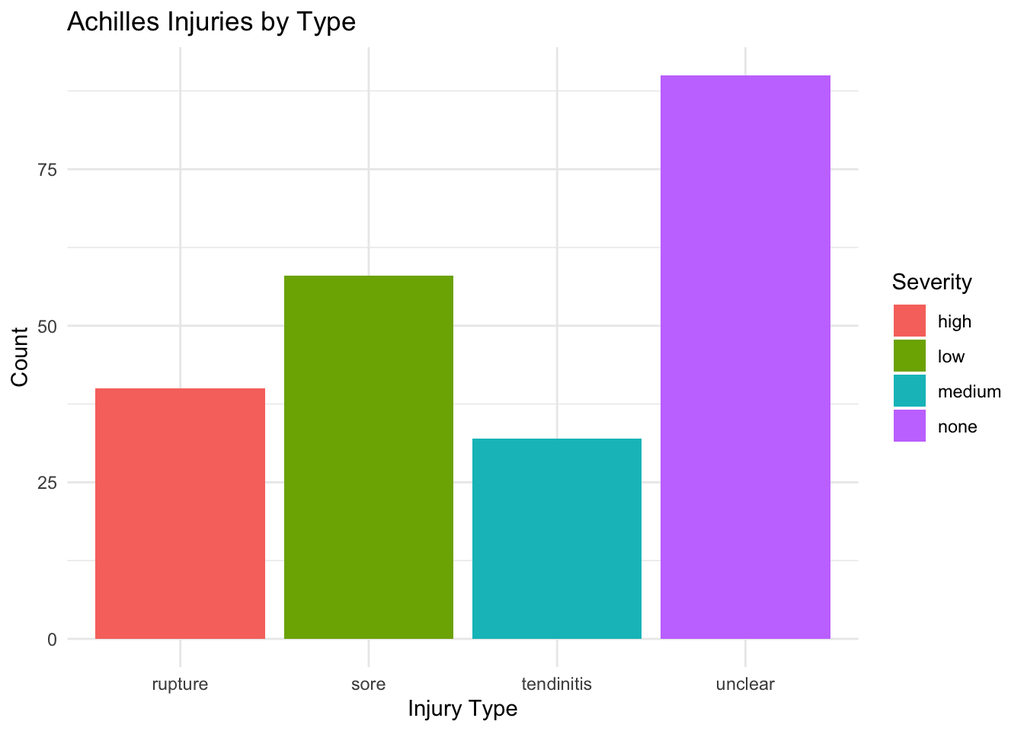

```r
### --- Quick viz on types of injury ---
# -> To check if there are any repeat entries of injuries --> (e.g Kevin Durant in 2019 and 2020)
# -> We only want to keep the first recorded injury time
ggplot(achilles_injuries_CONSOLIDATED,
       aes(x = injury_type,
           fill = injury_severity)
) +
  geom_bar() +
  labs(
    title = "Achilles Injuries by Type",
    x = "Injury Type",
    y = "Count",
    fill = "Severity"
  ) +
  theme_minimal()
```

```r
# Looking at unique players because they appear multiple times if they are out for
# more than one season (i.e Klay Thompson, KD etc.)
# So here we're looking for unique entries by keep only the earliest occurrence per player

achilles_unique_players <-
  achilles_injuries_CONSOLIDATED %>%
  arrange(player_name, injury_date) %>%
  distinct(player_name, .keep_all = TRUE)   # keep only the first occurrence per player

achilles_unique_players %>% head(3)
```

| injury_date | player_name | injury_desc | injury_type | injury_severity | achilles_rupture_binary |
| --- | --- | --- | --- | --- | --- |
| 2019-12-30 | Aaron Gordon | placed on IL with left Achilles injury | unclear | none | 0 |
| 2011-03-18 | Al Harrington | placed on IL with strained right Achilles tendon | unclear | none | 0 |
| 2014-12-25 | Anderson Varejao | placed on IL with left Achilles injury (out for season) | unclear | none | 0 |

- We then moved to checking for complete tears/ruptures and eliminating cases of tendinitis or strains from our list.

```r
# --- Checking for complete tears/ ruptures NOT tendinitis and strains... ---
achilles_injuries_CONSOLIDATED %>%
  filter(
    str_detect(tolower(injury_desc), "achilles"),
    achilles_rupture_binary == 0
  ) %>%
  select(injury_date, player_name, injury_desc) %>%
  arrange(injury_date) %>%
  head()
```

| injury_date | player_name | injury_desc |
| --- | --- | --- |
| 2002-01-07 | Patrick Ewing | placed on IR with right calf / Achilles tendinitis |
| 2002-02-26 | Quincy Lewis | placed on IL with left Achilles tendinitis |
| 2002-03-10 | Rafer Alston | placed on IR with sore right Achilles heel |
| 2002-04-17 | Ruben Patterson | placed on IR with sore Achilles tendons |
| 2002-10-28 | Jamie Feick | placed on IL with left Achilles tendon injury |
| 2002-10-28 | Chris Mills | placed on IL with left Achilles tendinitis |

```r
achilles_ruptures_final <-
  achilles_injuries_CONSOLIDATED %>%
  filter(achilles_rupture_binary == 1) %>%
  arrange(player_name, injury_date) %>%
  distinct(player_name, .keep_all = TRUE)
# --- 2002 to 2023: 32 unique Achilles injuries ---
n_distinct(achilles_ruptures_final$player_name)
```

```
## [1] 32
```

- At this stage, we are targeting only the Achilles Rupture injuries and the outcome is 32 incidents between 2002 to 2023

```r
modern_achilles_CLEANED <-
  achilles_ruptures_final %>%
  select(player_name, injury_date, injury_desc, injury_type, injury_severity, achilles_rupture_binary)

# --- Combine both sets [1990 to 2023] ---
achilles_ruptures_MERGED <-
  bind_rows(old_achilles_tear_CLEANED, modern_achilles_CLEANED)

# --- Check total unique injured players [1990 to 2023] ---
unique_achilles_injuries_TOTAL <-
  n_distinct(achilles_ruptures_MERGED$player_name)

library(glue)
glue("The number of players who suffered an Achilles tear from 1990 to 2023 was {unique_achilles_injuries_TOTAL}.")
```

```
## The number of players who suffered an Achilles tear from 1990 to 2023 was 45.
```

```r
write_csv(achilles_ruptures_MERGED, "achilles_ruptured_merged.csv")
```

- We then merge the data from 1990 to 2023 and we identified and cross validated the total number of players who suffered an Achilles tear were indeed 45 in line with (Kumar 2025). **Yay~**
- This list was curated by filtering historical NBA injury data for confirmed rupture keywords (e.g., ‘tear’, ‘surgery’, ‘repair’)

## 3. Explanatory Data Analysis

### Visualizing Achilles Ruptures

- To give the visualizations an authentic *“NBA feel”*, we built a **custom theme** for our NBA plots.

```r
pacman::p_load("showtext")


font_add_google("Roboto Condensed", "roboto")
showtext_auto()
```

```r
# --- Custom Function for our "NBA-themed" plot ---
# We tried to mirror the colors here:
# -> "#CE1141" --> red
# -> "#17408B" --> blue
# -> "#FFFFFF" --> white
# -> "#E0E0E0" --> light-grey
theme_nba <-
  function() {
  theme_minimal(base_family = "roboto") +
    theme(
      plot.background = element_rect(fill = "#FFFFFF", color = NA),
      panel.grid.major = element_line(color = "#E0E0E0"),
      panel.grid.minor = element_blank(),

      plot.title = element_text(face = "bold", size = 16, color = "black"),
      plot.subtitle = element_text(size = 12, color = "gray30"),

      plot.caption = element_text(size = 8, color = "black", face = "italic"),

      axis.title = element_text(face = "bold", size = 10),
      axis.text = element_text(size = 9),

      legend.position = "top",
      legend.direction = "horizontal",
      legend.title = element_text(face = "bold", size = 10, color = "black"),
      legend.text = element_text(size = 9, color = "black")
    )
}
```

- Plot Achilles Injuries by `Year`

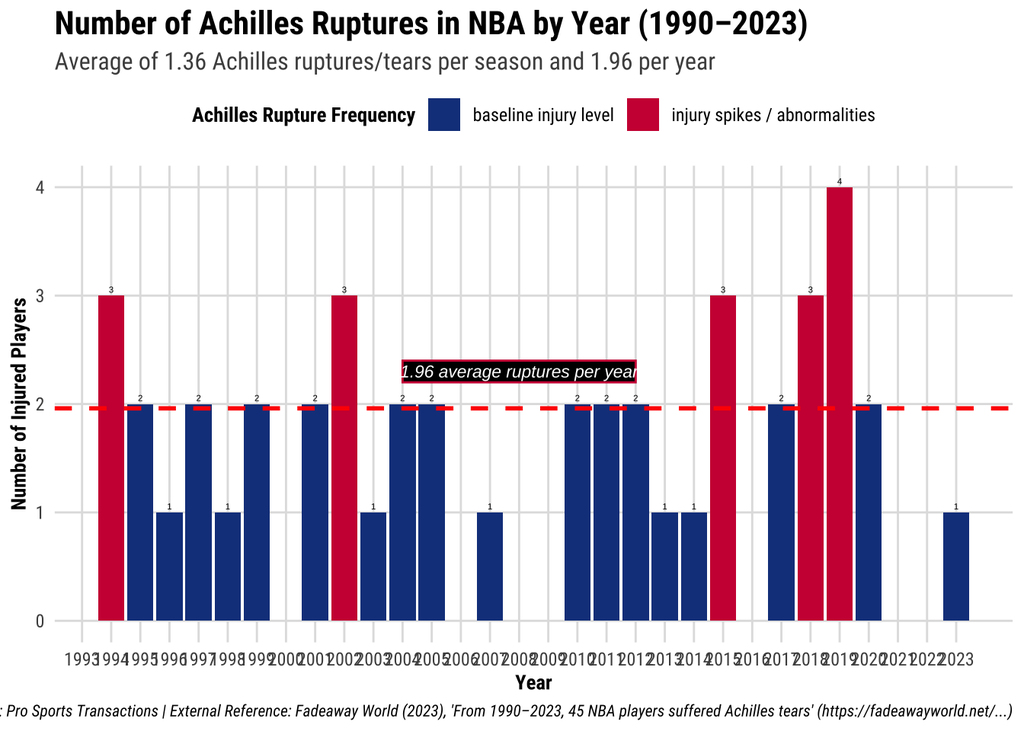

```r
AVERAGE_BY_YEAR <-
achilles_ruptures_MERGED %>%
  mutate(year = year(injury_date)
         ) %>%
  count(year) %>%
  summarise(avg_per_year = mean(n)
            )

achilles_ruptures_BY_YEAR_VIZ <-
  achilles_ruptures_MERGED %>%
  mutate(year = year(injury_date)
         ) %>%
  count(year) %>%
  mutate(fill_color = ifelse(n >= 3, "highlight", "base")
         ) %>%
  ggplot(aes(x = year,
             y = n,
             fill = fill_color)
  ) +
  geom_col() +
  scale_fill_manual(name = "Achilles Rupture Frequency",
                    values = c("highlight" = "#CE1141",
                               "base" = "#17408B"),
                    labels = c("highlight" = "injury spikes / abnormalities",
                               "base" = "baseline injury level")
                    )+
  geom_text(aes(label = n), vjust = -0.5, size = 1.5) +  # annotate bar heights
  scale_x_continuous(breaks = seq(1990,2023, by =1)
                     )+
  geom_hline(yintercept = 1.96, color = "red", linetype = "dashed", size = 1) +
  annotate("rect",
             xmin = 2004, xmax = 2012,
             ymin = 2.2, ymax = 2.4,
             fill = "black",
             alpha = 1,
             color = "#CE1141",
             size = 0.5) +
  annotate("text",
           x = 2008,
           y = 2.3,
           label = "1.96 average ruptures per year",
           color = "#FFFFFF",
           size = 3,
           fontface = "italic")+
    labs(title = "Number of Achilles Ruptures in NBA by Year (1990–2023)",
       subtitle = "Average of 1.36 Achilles ruptures/tears per season and 1.96 per year",
       x = "Year",
       y = "Number of Injured Players",
       caption = "Data: Pro Sports Transactions | External Reference: Fadeaway World (2023), 'From 1990–2023, 45 NBA players suffered Achilles tears' (https://fadeawayworld.net/...)"
  ) +
  theme(plot.caption = element_text(hjust = 0, size = 9, face = "italic"),
        axis.text.x = element_text(angle = 90, vjust = 0.5, hjust = 1)
  )+
  theme_nba()
achilles_ruptures_BY_YEAR_VIZ
```

- **[MANUAL IMPORT]**: Now to visualize the recent spike 2024 and 2025
- Checking list of players injured using scraped ESPN News Data

```r
players_with_achilles_injuries_ESPN <-
  espn_injury_CLEAN %>%
  filter(str_detect(tolower(COMMENT),"achilles")
         ) %>%
  select(NAME,COMMENT)

new_achilles_cases_2425 <-
  tribble(
    ~player_name,           ~injury_date,       ~injury_desc,                           ~injury_type, ~injury_severity,
    "Tyrese Haliburton",    "2025-06-22",       "reported torn right Achilles tendon",  "rupture",    "high",
    "Jayson Tatum",         "2025-05-12",       "reported torn right Achilles tendon",  "rupture",    "high",
    "Dejounte Murray",      "2025-01-31",       "reported torn right Achilles tendon",  "rupture",    "high",
    "Damian Lillard",       "2025-04-27",       "reported torn left Achilles tendon",   "rupture",    "high",
    "Isaiah Jackson",       "2024-11-01",       "reported torn right Achilles tendon",  "rupture",    "high",
    "James Wiseman",        "2024-10-23",       "reported torn left Achilles tendon",   "rupture",    "high",
    "Dru Smith",            "2024-12-23",       "reported ruptured left Achilles tendon","rupture",    "high",
    "DaRon Holmes II",      "2024-07-12",       "reported torn right Achilles tendon",  "rupture",    "high"
  ) %>%
  mutate(injury_date = ymd(injury_date)
  ) %>%
  mutate(achilles_rupture_binary = if_else(injury_type == "rupture", 1, 0)
  )

achilles_ruptures_recency_COMPARISON <-
  bind_rows(achilles_ruptures_MERGED, new_achilles_cases_2425)

achilles_ruptures_recency_COMPARISON %>%
  arrange(injury_date) %>%
  head()
```

| player_name | injury_date | injury_desc | injury_type | injury_severity | achilles_rupture_binary |
| --- | --- | --- | --- | --- | --- |
| Gerald Wilkins | 1994-11-03 | placed on IL with torn Achilles tendon | rupture | high | 1 |
| Stanley Roberts | 1994-11-03 | placed on IL with ruptured left Achilles tendon | rupture | high | 1 |
| Kevin Edwards | 1994-11-30 | placed on IR with partially torn left Achilles tendon | rupture | high | 1 |
| Felton Spencer | 1995-01-17 | place on IR with torn left Achilles tendon (out for season) | rupture | high | 1 |
| Scott Burrell | 1995-04-04 | placed on IR with partial tear of right Achilles tendon (out for season) | rupture | high | 1 |
| David Benoit | 1996-10-31 | placed on IL with torn right Achilles tendon | rupture | high | 1 |

```r
write_csv(achilles_ruptures_recency_COMPARISON, "achilles_ruptures_recency_COMPARISON.csv")
```

- Looking at that **JUMP** in 2024-2025 season
- *food for thought: We were wondering if RDD analysis to show this unnatural jump here could be advisable for a causal angle*

[figure not shown]

```r
achilles_ruptures_COMPARISON_VIZ <-
  achilles_ruptures_recency_COMPARISON %>%
  mutate(year = year(injury_date)
         ) %>%
  count(year) %>%
  mutate(fill_color = ifelse(n >= 3, "highlight", "base")
         ) %>%
  ggplot(aes(x = year,
             y = n,
             fill = fill_color)
         ) +
  geom_col() +
  scale_fill_manual(name = "Achilles Rupture Frequency",
                    values = c("highlight" = "#CE1141",
                               "base" = "#17408B"),
                    labels = c("highlight" = "injury spikes / abnormalities",
                               "base" = "baseline injury level")
                    )+
  geom_text(aes(label = n),
            vjust = -0.5,
            size = 1.5) +
  scale_x_continuous(breaks = seq(1990,2025, by = 1)
                     )+
  geom_hline(yintercept = 1.96, color = "red", linetype = "dashed", size = 1) +
  annotate("rect",
           xmin = 2004, xmax = 2012,
           ymin = 2.2, ymax = 2.4,
           fill = "black",
           alpha = 1,
           color = "#CE1141",
           size = 0.5) +
  annotate("text",
           x = 2008,
           y = 2.3,
           label = "1.96 average ruptures per year",
           color = "#FFFFFF",
           size = 3,
           fontface = "italic")+
  annotate("rect",
           xmin = 2023.5, xmax = 2024.5,
           ymin = 0, ymax = 4,
           fill = "orange", alpha = 0.6) +
  annotate("rect",
           xmin = 2024.5, xmax = 2025.5,
           ymin = 0, ymax = 4,
           fill = "orange", alpha = 0.6)+
  annotate("rect",
           xmin = 2015.5, xmax = 2025,
           ymin = 4.2, ymax = 4.6,
           fill = "black",
           alpha = 1,
           color = "#CE1141",
           size = 0.5)+
  annotate("text",
         x = 2020.5,
         y = 4.4,
         label = "Total Achilles Injuries in 2024-2025 season far superseded average of 1.36 ruptures \nper season with 8 ruptures in the past year thus far",
         color = "white",
         size = 3,
         fontface = "italic",
         hjust = 0.5)+
  labs(title = "Number of Achilles Ruptures in NBA by Year (1990–2023) Against Recent Jumps in 2024-2025 Season",
    subtitle = "Average of 1.36 Achilles ruptures/tears per season and 1.96 Achilles ruptures/tears per year",
    x = "Year",
    y = "Number of Injured Players",
    caption = paste(
      "Data: Pro Sports Transactions | External Reference: Fadeaway World (2023), 'From 1990–2023, 45 NBA players suffered Achilles tears'",
      "\nManual 2024–2025 injury data sourced from ESPN (espn.com) and Yahoo Sports (sports.yahoo.com)"
      )
    )+
  theme(plot.caption = element_text(hjust = 0, size = 9, face = "italic"),
        axis.text.x = element_text(angle = 90, vjust = 0.5, hjust = 1)
  )+
  theme_nba()

achilles_ruptures_COMPARISON_VIZ
```

### Preparation of Data to use for Modelling

> For modeling purposes, we restricted our dataset to `2002–2025 for NBA players` and `2009–2022 for NCAA athletes`. These ranges ensure consistent availability of game statistics and injury documentation.

> An additional 13 NBA cases from 1990–2001 were excluded from model training due to limited box score data but are acknowledged in descriptive summaries.

```r
### Merging it into a singular dataset to work with ----
box_scores_clean <-
  all_seasons_box %>%
  rename(player_name = athlete_display_name) %>%
  mutate(player_name = str_squish(player_name),
         game_date = as.Date(game_date)
  )
```

```r
## Merging NBA Achilles Injury Dataset 2002-2025 ----
achilles_ruptures_final %>% head() # 2002 to 2023
```

| injury_date | player_name | injury_desc | injury_type | injury_severity | achilles_rupture_binary |
| --- | --- | --- | --- | --- | --- |
| 2023-03-04 | Brandon Clarke | placed on IL with torn left Achilles tendon (out for season) | rupture | high | 1 |
| 2015-01-27 | Brandon Jennings | placed on IL with torn left Achilles (out for season) | rupture | high | 1 |
| 2018-09-21 | C.J. Wilcox | placed on IL with torn right Achilles tendon (out for season) | rupture | high | 1 |
| 2012-02-08 | Chauncey Billups | placed on IL with torn left Achilles tendon (out for season) | rupture | high | 1 |
| 2003-10-27 | Courtney Alexander | placed on IL with torn right Achilles tendon | rupture | high | 1 |
| 2005-12-19 | Dan Dickau | placed on IL with ruptured Achilles tendon (out for season) | rupture | high | 1 |

```r
new_achilles_cases_2425 %>% head() # 2024 to 2025
```

| player_name | injury_date | injury_desc | injury_type | injury_severity | achilles_rupture_binary |
| --- | --- | --- | --- | --- | --- |
| Tyrese Haliburton | 2025-06-22 | reported torn right Achilles tendon | rupture | high | 1 |
| Jayson Tatum | 2025-05-12 | reported torn right Achilles tendon | rupture | high | 1 |
| Dejounte Murray | 2025-01-31 | reported torn right Achilles tendon | rupture | high | 1 |
| Damian Lillard | 2025-04-27 | reported torn left Achilles tendon | rupture | high | 1 |
| Isaiah Jackson | 2024-11-01 | reported torn right Achilles tendon | rupture | high | 1 |
| James Wiseman | 2024-10-23 | reported torn left Achilles tendon | rupture | high | 1 |

```r
achilles_CASES_0225 <-
  bind_rows(achilles_ruptures_final, new_achilles_cases_2425)

player_achilles_flags <-
  achilles_CASES_0225 %>%
  distinct(player_name, .keep_all = TRUE) %>%
  mutate(injured_achilles = 1)

merged_data <-
  box_scores_clean %>%
  left_join(player_achilles_flags,
            by = "player_name") %>%
  mutate(injured_achilles = replace_na(injured_achilles, 0)
  )

merged_data_CLEANED <-
  merged_data %>%
  select(game_id, game_date, season, season_type, player_name, athlete_id, home_away,
         minutes, starter,points, rebounds, assists, steals, blocks, turnovers,
         fouls,injured_achilles
  ) %>%
  mutate(league = "NBA")
```

Engineering some **new features** for sensitivity analysis

> Looking at load: `rolling_minutes_3` → duration played for past 3 games → captures recent workload intensity.

> Looking at rest: `back_to_back` : Quantify recovery time — shorter rest may increase fatigue.

> Other factors: `home_away`: Controls for game location effects (travel fatigue, crowd, etc.).

```r
# building a function to add new variables all at one go (ensure uniformity in dataset later)
create_features <-
  function(df) {
    df %>%
      arrange(player_name, game_date) %>%
      group_by(player_name) %>%
      mutate(rolling_minutes_3 = lag(zoo::rollapplyr(minutes,
                                                     width = 3,
                                                     FUN = mean,
                                                     fill = NA,
                                                     partial = TRUE)
                                     ),
             days_since_last_game = as.numeric(game_date - lag(game_date)
                                        ),
             back_to_back = if_else(days_since_last_game == 1, 1, 0, missing = 0),
             days_rest = days_since_last_game,
             days_rest = if_else(is.na(days_rest),
                          median(days_since_last_game, na.rm = TRUE),
                          days_rest),
             cum_achilles_injuries = cumsum(lag(injured_achilles,
                                         default = 0)
                                         ),
             home_game = if_else(home_away == "home", 1, 0),
             # Replace NAs immediately here
             rolling_minutes_3 = if_else(is.na(rolling_minutes_3), 0, rolling_minutes_3),
             days_since_last_game = if_else(is.na(days_since_last_game),
                                            median(days_since_last_game, na.rm = TRUE),
                                            days_since_last_game),
             days_rest = if_else(is.na(days_rest), median(days_rest, na.rm = TRUE), days_rest)
             ) %>%
      ungroup()
    }

merged_data_FEATURES <-
  create_features(merged_data_CLEANED)

merged_data_FEATURES_CLEANED <-
  merged_data_FEATURES %>%
  select(-home_away, -days_since_last_game)

merged_data_FEATURES_CLEANED %>%
  glimpse()
```

```
## Rows: 1,626,492
## Columns: 22
## $ game_id               <int> 211031004, 211031004, 211102002, 211102002, 2111…
## $ game_date             <date> 2001-10-31, 2001-10-31, 2001-11-02, 2001-11-02,…
## $ season                <int> 2002, 2002, 2002, 2002, 2002, 2002, 2002, 2002, …
## $ season_type           <int> 2, 2, 2, 2, 2, 2, 2, 2, 2, 2, 2, 2, 2, 2, 2, 2, …
## $ player_name           <chr> "A.J. Guyton", "A.J. Guyton", "A.J. Guyton", "A.…
## $ athlete_id            <int> 288, 288, 288, 288, 288, 288, 288, 288, 288, 288…
## $ minutes               <dbl> 7, 7, 5, 5, NA, NA, 12, 12, 14, 14, NA, NA, 6, 6…
## $ starter               <lgl> FALSE, FALSE, FALSE, FALSE, FALSE, FALSE, FALSE,…
## $ points                <int> 0, 0, 3, 3, NA, NA, 2, 2, 8, 8, NA, NA, 0, 0, 4,…
## $ rebounds              <int> 1, 1, 0, 0, NA, NA, 2, 2, 1, 1, NA, NA, 0, 0, 1,…
## $ assists               <int> 1, 1, 1, 1, NA, NA, 0, 0, 2, 2, NA, NA, 0, 0, 2,…
## $ steals                <int> 0, 0, 0, 0, NA, NA, 1, 1, 0, 0, NA, NA, 0, 0, 0,…
## $ blocks                <int> 0, 0, 0, 0, NA, NA, 0, 0, 0, 0, NA, NA, 0, 0, 0,…
## $ turnovers             <int> 0, 0, 0, 0, NA, NA, 0, 0, 0, 0, NA, NA, 2, 2, 1,…
## $ fouls                 <int> 0, 0, 0, 0, NA, NA, 0, 0, 0, 0, NA, NA, 2, 2, 0,…
## $ injured_achilles      <dbl> 0, 0, 0, 0, 0, 0, 0, 0, 0, 0, 0, 0, 0, 0, 0, 0, …
## $ league                <chr> "NBA", "NBA", "NBA", "NBA", "NBA", "NBA", "NBA",…
## $ rolling_minutes_3     <dbl> 0.000000, 7.000000, 7.000000, 6.333333, 5.666667…
## $ back_to_back          <dbl> 0, 0, 0, 0, 1, 0, 0, 0, 1, 0, 0, 0, 0, 0, 0, 0, …
## $ days_rest             <dbl> 0, 0, 2, 0, 1, 0, 4, 0, 1, 0, 13, 0, 3, 0, 3, 0,…
## $ cum_achilles_injuries <dbl> 0, 0, 0, 0, 0, 0, 0, 0, 0, 0, 0, 0, 0, 0, 0, 0, …
## $ home_game             <dbl> 1, 1, 0, 0, 1, 1, 1, 1, 0, 0, 0, 0, 0, 0, 0, 0, …
```

> Adding another feature: whether they were ever injured or not before

```r
past_injuries_detection <-
  injuries %>%
  rename(injury_date = Date,
         player_name_1 = Relinquished,
         player_name_2 = Acquired,
         injury_desc = Notes
         ) %>%
  mutate(player_name = coalesce(player_name_1, player_name_2),
         player_name = str_squish(str_remove_all(player_name, "\\(.*\\)")),
         injury_date = as.Date(injury_date)
         ) %>%
  filter(!is.na(player_name), !is.na(injury_date)
         ) %>%
  select(injury_date, player_name, injury_desc)
```

> Create player-level ever-injured flag

```r
injury_flags <-
  past_injuries_detection %>%
  distinct(player_name) %>%
  mutate(ever_injured = 1)

merged_data_FEATURES_CLEANED <-
  merged_data_FEATURES_CLEANED %>%
  left_join(injury_flags, by = "player_name") %>%
  mutate(ever_injured = replace_na(ever_injured, 0)
         )
```

For the 2024-2025 injuries

```r
espn_ever_injured_flags <-
  espn_injury_CLEAN %>%
  distinct(NAME) %>%
  rename(player_name = NAME) %>%
  mutate(ever_injured = 1)


merged_data_FEATURES_CLEANED <-
  merged_data_FEATURES_CLEANED %>%
  left_join(espn_ever_injured_flags,
            by = "player_name",
            suffix = c("", "_espn")
            ) %>%
  mutate(ever_injured = if_else(is.na(ever_injured) & !is.na(ever_injured_espn), 1,
      coalesce(ever_injured, 0)
    )
  ) %>%
  select(-ever_injured_espn)
```

- Aggregating Data by Player and Season (NBA)

```r
nba_agg_player_season <-
  merged_data_FEATURES_CLEANED %>%
  dplyr::group_by(player_name, season) %>%
  dplyr::summarize(rolling_minutes_3 = mean(rolling_minutes_3, na.rm = TRUE),
                   total_minutes = sum(minutes, na.rm = TRUE),
                   total_points = sum(points, na.rm = TRUE),
                   total_rebounds = sum(rebounds, na.rm = TRUE),
                   total_assists = sum(assists, na.rm = TRUE),
                   total_steals = sum(steals, na.rm = TRUE),
                   total_blocks = sum(blocks, na.rm = TRUE),
                   total_turnovers = sum(turnovers, na.rm = TRUE),
                   total_fouls = sum(fouls, na.rm = TRUE),
                   back_to_back_games = sum(back_to_back, na.rm = TRUE),
                   injured_achilles = max(injured_achilles),
                   games_played = n(),
                   .groups = "drop")
```

–> Here the NCAA injuries were individually sourced and collated because there were many sites that were blocked for scraping. In the future, we would like to build an automated scraper across various sources for efficient data collection

```r
### [MANUAL IMPORT}: Now to import NCAA Achilles Injuries to enhance our dataset
# ==> to find out ground truth ====
ncaa_achilles_ruptures <-
  read_csv("ncaa_achilles_ruptures.csv")
ncaa_achilles_ruptures %>%
  glimpse()
```

```
## Rows: 21
## Columns: 10
## $ player_name             <chr> "Brandon Johnson", "Junior Cadougan", "Kalin L…
## $ injury_date             <chr> "6/12/08", "18/9/09", "22/10/10", "7/1/12", "1…
## $ injury_desc             <chr> "season-ending Achilles tendon rupture", "repo…
## $ injury_type             <chr> "rupture", "rupture", "rupture", "rupture", "r…
## $ injury_severity         <chr> "high", "high", "high", "high", "high", "high"…
## $ achilles_rupture_binary <dbl> 1, 1, 1, 1, 1, 1, 1, 1, 1, 1, 1, 1, 1, 1, 1, 1…
## $ school                  <chr> "San Diego", "Marquette", "Michigan", "Tulane"…
## $ class                   <chr> "senior", "sophmore", "junior", "junior", "sen…
## $ position                <chr> "guard", "guard", "guard", "guard", "guard", "…
## $ source                  <chr> "https://www.sandiegouniontribune.com/2009/03/…
```

```r
clean_player_name <-
  function(x) {
    x %>%
      str_squish() %>%
      str_to_lower() %>%
      str_replace_all("[^[:alnum:] ]", "")
    }

ncaa_achilles_ruptures_CLEAN <-
  ncaa_achilles_ruptures %>%
  mutate(across(where(is.character), ~ str_replace_all(., '^"|"$', ''))
  ) %>%
  mutate(
    player_name = clean_player_name(player_name),
    injury_desc = str_replace_all(injury_desc, "[^[:alnum:] [:space:]'-.,]", ""),
    injury_date = dmy(injury_date),
    injury_year = year(injury_date)
  ) %>%
  select(-source)

ncaa_achilles_ruptures_CLEAN %>%
  head()
```

| player_name | injury_date | injury_desc | injury_type | injury_severity | achilles_rupture_binary | school | class | position | injury_year |
| --- | --- | --- | --- | --- | --- | --- | --- | --- | --- |
| brandon johnson | 2008-12-06 | season-ending Achilles tendon rupture | rupture | high | 1 | San Diego | senior | guard | 2.01e+03 |
| junior cadougan | 2009-09-18 | reported a torn right Achilles | rupture | high | 1 | Marquette | sophmore | guard | 2.01e+03 |
| kalin lucas | 2010-10-22 | ruptured the Achilles tendon in his left foot | rupture | high | 1 | Michigan | junior | guard | 2.01e+03 |
| kendall timmons | 2012-01-07 | rupturedright Achilles tendon | rupture | high | 1 | Tulane | junior | guard | 2.01e+03 |
| tim frazier | 2012-11-18 | torn left Achilles tendon | rupture | high | 1 | Penn State | senior | guard | 2.01e+03 |
| devonta abron | 2013-08-20 | Torn Achilles tendon, season-ending | rupture | high | 1 | TCU Horned Frogs | junior | guard | 2.01e+03 |

```r
unique_ncaa_achilles_ruptures <-
  n_distinct(ncaa_achilles_ruptures_CLEAN$player_name)

glue(paste0("Achilles Injuries occuring in NCAA were not widely reported before 2000s. The prevalence of such reports came in 2005 onwards",
            ". The researched number of NCAA basketball players who suffered an Achilles tear from the 2000s (2008 to 2025) was {unique_ncaa_achilles_ruptures}.")
)
```

```
## Achilles Injuries occuring in NCAA were not widely reported before 2000s. The prevalence of such reports came in 2005 onwards. The researched number of NCAA basketball players who suffered an Achilles tear from the 2000s (2008 to 2025) was 21.
```

```r
### ==== NCAA player level data ====
## From Kaggle Dataset: Player level data (input features)
ncaa_0921 <-
  read_csv("CollegeBasketballPlayers2009-2021.csv")
ncaa_0921 <-
  read_csv("CollegeBasketballPlayers2022.csv")
```

```
## ──────────────────────────────────────────────────────── Delimiter: "," chr
## (8): player_name, team, conf, yr, ht, num, type, ...65 dbl (57): GP, Min_per,
## Ortg, usg, eFG, TS_per, ORB_per, DRB_per, AST_per, TO... lgl (1): pick
```

```r
ncaa_0922 <-
  bind_rows(ncaa_0921,ncaa_0921)
```

- Now to merge with `ncaa_achilles_ruptures_CLEAN`

```r
# Clean player stats
ncaa_stats_CLEAN <-
  ncaa_0922 %>%
  mutate(player_name = clean_player_name(player_name),
         season = as.integer(year)
  )
```

```r
# Clean injury data
ncaa_injuries_CLEAN <-
  ncaa_achilles_ruptures_CLEAN %>%
  mutate(player_name = clean_player_name(player_name),
         injury_year = year(injury_date)
  )
```

```r
# Join injuries to stats
ncaa_stats_MERGED <-
  ncaa_stats_CLEAN %>%
  left_join(
    ncaa_injuries_CLEAN %>%
      select(player_name, injury_date, injury_year, injury_type, injury_severity, achilles_rupture_binary),
    by = "player_name"
  ) %>%
  mutate(achilles_rupture_flag = if_else(!is.na(achilles_rupture_binary),
                                         achilles_rupture_binary, 0)
  )

ncaa_stats_MERGED <-
  ncaa_stats_MERGED %>%
  mutate(achilles_rupture_flag = replace_na(achilles_rupture_flag, 0),
         achilles_rupture_binary = replace_na(achilles_rupture_binary, 0)
  )
```

```r
# Create proxy injury flags for each game (all games in NCAA are season-level, so make game_date)
ncaa_stats_MERGED <-
  ncaa_stats_MERGED %>%
  mutate(game_date = as.Date(paste0(season, "-01-15")
                             ),
         injured_achilles = achilles_rupture_flag,
         injured_this_game = injured_achilles,
         rebounds = DRB_per + ORB_per
         )
```

```r
# Select relevant columns, rename to consistency for merging later
ncaa_CLEAN <-
  ncaa_stats_MERGED %>%
  select(player_name, game_date, season,
         minutes = Min_per, points = pts, rebounds,
         assists = AST_per, injured_achilles, injured_this_game
  ) %>%
  mutate(league = "NCAA")
```

```r
# See injured player rows
injured_ncaa <-
  ncaa_stats_MERGED %>%
  filter(achilles_rupture_flag == 1) %>%
  select(player_name, team, season, injury_type, injury_severity, everything()
  ) %>%
  arrange(player_name, injury_date) %>%
  distinct(player_name, .keep_all = TRUE)

nrow(injured_ncaa) == nrow(ncaa_achilles_ruptures_CLEAN) # cross validating our numbers
```

```
## [1] FALSE
```

```r
# Missing players from injury dataset
missing_players <-
  ncaa_achilles_ruptures_CLEAN %>%
  mutate(
    player_name = str_squish(str_to_lower(player_name)),
    player_name = str_replace_all(player_name, "[^[:alnum:] ]", "")
  ) %>%
  anti_join(ncaa_stats_MERGED, by = "player_name")

missing_players %>%
  select(player_name, injury_date)
```

| player_name | injury_date |
| --- | --- |
| junior cadougan | 2009-09-18 |
| kalin lucas | 2010-10-22 |
| kendall timmons | 2012-01-07 |
| tim frazier | 2012-11-18 |
| devonta abron | 2013-08-20 |
| josh brown | 2016-05-20 |
| marcus evans | 2018-06-04 |
| jaquan lyle | 2018-09-29 |
| alex tchikou | 2020-10-19 |
| adrian ace baldwin jr | 2021-06-01 |
| terrance arceneaux | 2023-12-19 |
| jeff nwankwo | 2024-07-21 |
| kj adams jr | 2025-03-20 |

```r
missing_players_prepped <-
  missing_players %>%
  mutate(season = year(injury_date),
         game_date = injury_date,
         minutes = NA_real_,
         points = NA_real_,
         rebounds = NA_real_,
         assists = NA_real_,
         injured_achilles = 1,
         injured_this_game = 1,
         league = "NCAA",
         achilles_rupture_flag = 1,
         achilles_rupture_binary = 1) %>%
  select(any_of(names(ncaa_stats_MERGED)
                )
         )
```

```r
# Combine with main stats dataset
ncaa_stats_extended <-
  bind_rows(ncaa_stats_MERGED, missing_players_prepped) %>%
  distinct(player_name, season, game_date, .keep_all = TRUE)

# for cross validation of number of injured ncaa players
ncaa_achilles_merged <-
  ncaa_stats_extended %>%
  filter(achilles_rupture_flag == 1) %>%
  select(player_name,injury_date, achilles_rupture_flag) %>%
  arrange(player_name, injury_date) %>%
  distinct(player_name, .keep_all = TRUE)
```

```r
# Cross-checking number of Achilles tear/rupture cases in ncaa data (09-22)
unique_ncaa_achilles_ruptures == nrow(ncaa_achilles_merged)
```

```
## [1] TRUE
```

```r
write_csv(ncaa_stats_extended, "ncaa_stats_extended.csv")
```

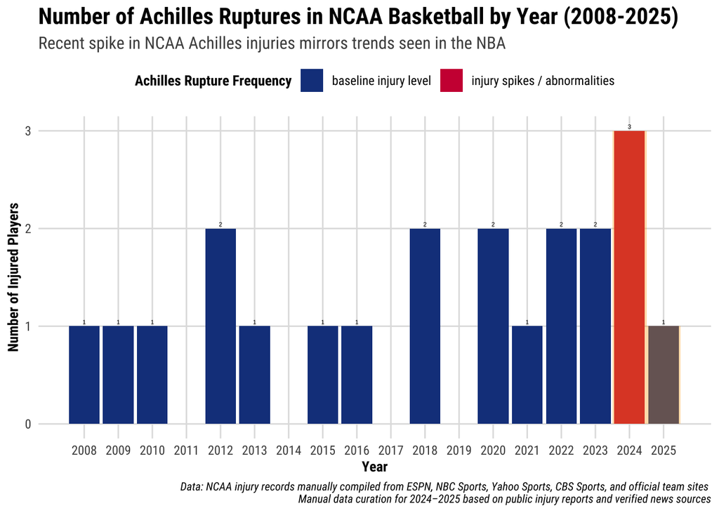

```r
### ---- VISUALIZE NCAA Achilles Ruptures/ Tears Injuries ----
ncaa_achilles_VIZ <-
  ncaa_achilles_merged %>%
  mutate(year = year(injury_date)
         ) %>%
  count(year) %>%
  mutate(fill_color = ifelse(n >= 3, "highlight", "base")
         ) %>%
  ggplot(aes(x = year,
             y = n,
             fill = fill_color)
         )+
  geom_col()+
  scale_fill_manual(name = "Achilles Rupture Frequency",
                    values = c("highlight" = "#CE1141",
                               "base" = "#17408B"),
                    labels = c("highlight" = "injury spikes / abnormalities",
                               "base" = "baseline injury level")
                    )+
  geom_text(aes(label = n),
            vjust = -0.5,
            size = 1.5) +
  scale_x_continuous(breaks = seq(2008,2025, by = 1)
                     )+
  annotate("rect",
           xmin = 2023.5, xmax = 2024.5,
           ymin = 0, ymax = 3,
           fill = "orange", alpha = 0.35) +
  annotate("rect",
           xmin = 2024.5, xmax = 2025.5,
           ymin = 0, ymax = 1,
           fill = "orange", alpha = 0.35)+
  labs(title = "Number of Achilles Ruptures in NCAA Basketball by Year (2008-2025)",
       subtitle = "Recent spike in NCAA Achilles injuries mirrors trends seen in the NBA",
       x = "Year",
       y = "Number of Injured Players",
       caption = paste(
         "Data: NCAA injury records manually compiled from ESPN, NBC Sports, Yahoo Sports, CBS Sports, and official team sites",
         "\nManual data curation for 2024–2025 based on public injury reports and verified news sources"
       )
  )+
  theme(plot.caption = element_text(hjust = 0, size = 9, face = "italic"),
        axis.text.x = element_text(angle = 90, vjust = 0.5, hjust = 1)
  )+
  theme_nba()
ncaa_achilles_VIZ
```

```r
# NCAA dataset cleaning
ncaa_CLEAN <-
  ncaa_stats_extended %>%
  mutate(league = "NCAA") %>%
  select(player_name,
         game_date,
         minutes = Min_per,
         points = pts,
         rebounds,assists = AST_per,
         injured_achilles,
         injured_this_game,
         injury_date,
         league
  ) %>%
  arrange(player_name,injury_date) %>%
  distinct(player_name, .keep_all = TRUE)

ncaa_CLEAN %>% glimpse()
```

```
## Rows: 3,976
## Columns: 10
## $ player_name       <chr> "aanen moody", "aaron clarke", "aaron cook", "aaron …
## $ game_date         <date> 2022-01-15, 2022-01-15, 2022-01-15, 2022-01-15, 202…
## $ minutes           <dbl> 27.8, 69.9, 31.4, 22.1, 33.6, 10.0, 2.0, 10.1, 51.9,…
## $ points            <dbl> 5.1500, 13.2500, 4.2333, 1.5833, 3.5000, 3.1111, 0.4…
## $ rebounds          <dbl> 10.2, 5.0, 13.4, 11.8, 14.1, 18.6, 6.4, 30.8, 5.0, 9…
## $ assists           <dbl> 7.0, 19.6, 17.3, 16.1, 27.0, 10.5, 0.0, 6.3, 11.3, 3…
## $ injured_achilles  <dbl> 0, 0, 0, 0, 0, 0, 0, 0, 0, 0, 0, 0, 0, 0, 0, 0, 0, 0…
## $ injured_this_game <dbl> 0, 0, 0, 0, 0, 0, 0, 0, 0, 0, 0, 0, 0, 0, 0, 0, 0, 0…
## $ injury_date       <date> NA, NA, NA, NA, NA, NA, NA, NA, NA, NA, NA, NA, NA,…
## $ league            <chr> "NCAA", "NCAA", "NCAA", "NCAA", "NCAA", "NCAA", "NCA…
```

```r
# Adding Features to the NCAA Dataset [Similar to NBA]
create_ncaa_features <-
  function(df) {
  df %>%
    arrange(player_name, game_date) %>%
    group_by(player_name) %>%
    mutate(rolling_minutes_3 = lag(zoo::rollapplyr(minutes,
                                                   width = 3,
                                                   FUN = mean,
                                                   fill = NA,
                                                   partial = TRUE)
                              ),
      days_since_last_game = as.numeric(game_date - lag(game_date)
                                        ),
      back_to_back = if_else(days_since_last_game == 1, 1, 0, missing = 0),
      days_rest = days_since_last_game,
      days_rest = if_else(is.na(days_rest), median(days_since_last_game, na.rm = TRUE), days_rest),
      cum_achilles_injuries = cumsum(lag(injured_achilles, default = 0)),
      # For NCAA, set home_game here ==> default we use home
      home_game = 0,
      # Replace NAs immediately here
      rolling_minutes_3 = if_else(is.na(rolling_minutes_3), 0, rolling_minutes_3),
      days_since_last_game = if_else(is.na(days_since_last_game),
                                     median(days_since_last_game, na.rm = TRUE),
                                     days_since_last_game),
      days_rest = if_else(is.na(days_rest), median(days_rest, na.rm = TRUE), days_rest)
    ) %>%
    ungroup()
  }

ncaa_CLEAN_FEATURES <-
  create_ncaa_features(ncaa_CLEAN)

ncaa_for_merge <-
  ncaa_CLEAN_FEATURES %>%
  select(player_name, game_date, minutes, points, rebounds, assists,
         injured_achilles, rolling_minutes_3,
         back_to_back, days_rest, cum_achilles_injuries, home_game,
         league
         ) %>%
  mutate(season = year(game_date)
         )
```

```r
## --- [NCAA] Aggregating Data by Player and Season ----
ncaa_agg_data <-
  ncaa_for_merge %>%
  dplyr::group_by(player_name, season) %>%
  dplyr::summarize(rolling_minutes_3 = mean(rolling_minutes_3, na.rm = TRUE),
                   total_minutes = sum(minutes, na.rm = TRUE),
                   total_points = sum(points, na.rm = TRUE),
                   total_rebounds = sum(rebounds, na.rm = TRUE),
                   total_assists = sum(assists, na.rm = TRUE),
                   injured_achilles = max(injured_achilles),
                   back_to_back = mean(back_to_back, na.rm = TRUE),
                   days_rest = mean(days_rest, na.rm = TRUE),
                   cum_achilles_injuries = max(cum_achilles_injuries, na.rm = TRUE),
                   games_played = n(),
                   .groups = "drop"
  )
```

```r
# Cleaning NBA dataset
nba_agg_clean <-
  nba_agg_player_season %>%
  mutate(
    league = "NBA"
  ) %>%
  arrange(player_name)
```

```r
### --- FINAL DATASET MERGE ----
nba_ncaa_FINAL_MERGE <-
  bind_rows(nba_agg_clean, ncaa_agg_data) %>%
  select(-back_to_back, -days_rest, -cum_achilles_injuries) %>%
  glimpse()
```

```
## Rows: 16,003
## Columns: 15
## $ player_name        <chr> "A.J. Guyton", "A.J. Guyton", "A.J. Lawson", "A.J. …
## $ season             <dbl> 2002, 2003, 2023, 2024, 2025, 2010, 2011, 2012, 201…
## $ rolling_minutes_3  <dbl> 8.782486, 3.277778, 1.465517, 3.421811, 16.517857, …
## $ total_minutes      <dbl> 1214, 18, 218, 686, 970, 1726, 1756, 1148, 2552, 19…
## $ total_points       <dbl> 488, 0, 112, 294, 472, 820, 730, 348, 882, 88, 266,…
## $ total_rebounds     <dbl> 88, 0, 42, 106, 172, 176, 158, 126, 228, 20, 64, 90…
## $ total_assists      <dbl> 162, 4, 4, 40, 62, 212, 234, 174, 410, 26, 92, 44, …
## $ total_steals       <int> 20, 2, 4, 20, 26, 70, 64, 40, 66, 2, 14, 12, 18, 76…
## $ total_blocks       <int> 14, 0, 0, 8, 12, 6, 2, 4, 6, 0, 0, 0, 8, 16, 24, 4,…
## $ total_turnovers    <int> 74, 2, 6, 28, 30, 118, 120, 64, 128, 14, 28, 18, 26…
## $ total_fouls        <int> 46, 0, 22, 46, 88, 106, 132, 60, 146, 10, 30, 62, 1…
## $ back_to_back_games <dbl> 17, 0, 2, 10, 4, 22, 21, 23, 20, 14, 9, 8, 13, 15, …
## $ injured_achilles   <dbl> 0, 0, 0, 0, 0, 0, 0, 0, 0, 0, 0, 0, 0, 0, 0, 0, 0, …
## $ games_played       <int> 118, 6, 58, 162, 56, 164, 174, 154, 152, 110, 70, 1…
## $ league             <chr> "NBA", "NBA", "NBA", "NBA", "NBA", "NBA", "NBA", "N…
```

```r
injury_per_player <-
  nba_ncaa_FINAL_MERGE %>%
  group_by(player_name) %>%
  dplyr::summarize(injured_achilles = max(injured_achilles),
                   .groups = "drop") %>%
  count(injured_achilles) %>%
  mutate(prop = n / sum(n) * 100)

nba_ncaa_FINAL_MERGE %>% glimpse()
```

```
## Rows: 16,003
## Columns: 15
## $ player_name        <chr> "A.J. Guyton", "A.J. Guyton", "A.J. Lawson", "A.J. …
## $ season             <dbl> 2002, 2003, 2023, 2024, 2025, 2010, 2011, 2012, 201…
## $ rolling_minutes_3  <dbl> 8.782486, 3.277778, 1.465517, 3.421811, 16.517857, …
## $ total_minutes      <dbl> 1214, 18, 218, 686, 970, 1726, 1756, 1148, 2552, 19…
## $ total_points       <dbl> 488, 0, 112, 294, 472, 820, 730, 348, 882, 88, 266,…
## $ total_rebounds     <dbl> 88, 0, 42, 106, 172, 176, 158, 126, 228, 20, 64, 90…
## $ total_assists      <dbl> 162, 4, 4, 40, 62, 212, 234, 174, 410, 26, 92, 44, …
## $ total_steals       <int> 20, 2, 4, 20, 26, 70, 64, 40, 66, 2, 14, 12, 18, 76…
## $ total_blocks       <int> 14, 0, 0, 8, 12, 6, 2, 4, 6, 0, 0, 0, 8, 16, 24, 4,…
## $ total_turnovers    <int> 74, 2, 6, 28, 30, 118, 120, 64, 128, 14, 28, 18, 26…
## $ total_fouls        <int> 46, 0, 22, 46, 88, 106, 132, 60, 146, 10, 30, 62, 1…
## $ back_to_back_games <dbl> 17, 0, 2, 10, 4, 22, 21, 23, 20, 14, 9, 8, 13, 15, …
## $ injured_achilles   <dbl> 0, 0, 0, 0, 0, 0, 0, 0, 0, 0, 0, 0, 0, 0, 0, 0, 0, …
## $ games_played       <int> 118, 6, 58, 162, 56, 164, 174, 154, 152, 110, 70, 1…
## $ league             <chr> "NBA", "NBA", "NBA", "NBA", "NBA", "NBA", "NBA", "N…
```

> All this just to say we are ready to model with our data. Moving forward, we will cover grounds covered in Modules 4 through 6. This is with a slight introduction and attempt at a causal angle based on the capstone guide example. We aim to expand on it further as we progress and ultimately address this issue and glean not just theoretical but real-life actionable insights that the NBA leaders are after.

## 4. [Sneak Peak] Causal Angle: Using DiD to investigate the effect of load on Achilles injuries —-

> Despite being medically rare, Achilles tendon ruptures among elite basketball players have grown **alarmingly frequent—seven such injuries** occurred in the NBA during the recent season, compared to none the previous year and a historical high of four (Reynolds 2025)

> This surge has prompted the league to convene an expert panel, signaling that  
> **Achilles ruptures are not just outliers**—they demand proactive detection and intervention.

> An additional thing the NBA leadership is exploring is whether modern training habits—particularly increasingly intense off-season and preseason workloads—are contributing to this uptick (Press 2025)

> This is something which we could not gain access to data to. The ground is being shifted for NBA here. We can expect to see more players with higher levels of fatigue at a younger age to experience various extents of injuries.

> But for now, our focus will be on a **notable unprecedented increase** in Achilles tears. What we intend to do here is do add a *quick causal layer to our analysis* to capture the **WHY portion of Achilles ruptures** in the league.

> Such insights lay the groundwork for predictive models, which can flag individual players at heightened risk and guide proactive interventions in training, load management, and rehabilitation. (WHO and in future we hope to say WHEN)

```r
# Defining Treatment and Time
# metrics such as load --> rolling minutes & back_to_back_games --> chosen based on Commissioner Adam Silver's speech
# --> TREATED: player-season where load was high (placeholder look at top 25% of player–seasons by rolling_minutes_3.)

# Define high load treatment group

nba_season_agg <-
  nba_agg_clean %>%
  group_by(player_name, season) %>%
  summarise(avg_rolling_minutes_3 = mean(rolling_minutes_3, na.rm = TRUE),
            injury =injured_achilles,
            total_minutes = total_minutes,
            back_to_back_games = back_to_back_games
            ) %>%
  ungroup()
nba_season_agg <-
  nba_season_agg %>%
  mutate(high_load = ifelse(avg_rolling_minutes_3 >= quantile(avg_rolling_minutes_3,
                                                              0.75, na.rm = TRUE),
                            1, 0)
  )
```

```r
# creating before and after
nba_season_agg <-
  nba_season_agg %>%
  arrange(player_name, season) %>%
  group_by(player_name) %>%
  mutate(season_num = as.numeric(season),
         post = lead(season_num, 1) == season_num + 1 & !is.na(lead(injury)
                                                               ) # indicator for next season after load season
  ) %>%
  ungroup()

# high load vs low load
nba_season_agg %>%
  count(high_load)
```

| high_load | n |
| --- | --- |
| 0 | 9020 |
| 1 | 3007 |

```r
nba_season_agg <-
  nba_season_agg %>%
  mutate(load_factor = factor(high_load, levels = c(0, 1),
                              labels = c("Low Load", "High Load")
  ),
  post_factor = factor(post, levels = c(FALSE, TRUE),
                       labels = c("Pre", "Post")
                       ),
  b2b_factor = factor(back_to_back_games, levels = c(0,1),
                      labels = c("No B2B", "B2B")
                      )
  )
```

Simplistic version of a DiD Modelling: > Conceptually, our model in a two-period setting can be written as:

**Model 1: Simple Difference-in-Differences (High vs Low Load)**

$$\hat{\text{injury}}_{it} = \hat{\beta}_0 + \hat{\beta}_3 \,
(\text{load\_factor}_i \times \text{post\_factor}_t) + \epsilon_{it}$$

**Model 2: Interaction Effects with Back-to-Back Games**

$$\hat{\text{injury}}_{it} = \hat{\beta}_0 + \hat{\beta}_7 \,
(\text{load\_factor}_i \times \text{post\_factor}_t \times
\text{b2b\_factor}_i) + \epsilon_{it}$$

```r
# -> Model 1: Simple DiD (High vs Low Load)
model1 <-
  lm(injury ~ load_factor * post_factor,
     data = nba_season_agg)

# -> Model 2: Interaction Effects with `back_to_back_games`
nba_season_agg <-
  nba_season_agg %>%
  mutate(b2b_factor = case_when(back_to_back_games == 1 ~ "B2B",
                                TRUE ~ "No B2B"
                                ),
    b2b_factor = factor(b2b_factor, levels = c("No B2B", "B2B"))
  )

table(nba_season_agg$b2b_factor, useNA = "ifany")
```

```
##
## No B2B    B2B
##  11661    366
```

```r
model2 <- lm(injury ~ load_factor * post_factor * b2b_factor,
             data = nba_season_agg)
```

```r
library(jtools)

export_summs(
  model1, model2,
  model.names = c(
    "Model 1:\nHigh vs Low Load (DID)",
    "Model 2:\nHigh vs Low × Post × B2B (DID)"
  ),
  error_format = "CIs: [{conf.low} ~ {conf.high}]"
)
```

|  | Model 1: High vs Low Load (DID) | Model 2: High vs Low × Post × B2B (DID) |
| --- | --- | --- |
| (Intercept) | 0.01 *** | 0.01 *** |
|  | CIs: [0.01 ~ 0.02] | CIs: [0.00 ~ 0.02] |
| load_factorHigh Load | 0.05 *** | 0.05 *** |
|  | CIs: [0.03 ~ 0.08] | CIs: [0.03 ~ 0.08] |
| post_factorPost | 0.01 | 0.01 |
|  | CIs: [-0.00 ~ 0.01] | CIs: [-0.00 ~ 0.01] |
| load_factorHigh Load:post_factorPost | -0.02 * | -0.03 * |
|  | CIs: [-0.05 ~ -0.00] | CIs: [-0.05 ~ -0.00] |
| b2b_factorB2B |  | 0.00 |
|  |  | CIs: [-0.01 ~ 0.02] |
| load_factorHigh Load:b2b_factorB2B |  | -0.07 |
|  |  | CIs: [-0.20 ~ 0.06] |
| post_factorPost:b2b_factorB2B |  | -0.02 |
|  |  | CIs: [-0.06 ~ 0.01] |
| load_factorHigh Load:post_factorPost:b2b_factorB2B |  | 0.19 * |
|  |  | CIs: [0.01 ~ 0.36] |
| N | 12027 | 12027 |
| R2 | 0.01 | 0.01 |
| *** p < 0.001; ** p < 0.01; * p < 0.05. |  |  |

Results of DID Regression — Achilles Injury Risk

> **Overall DID Effect (High vs Low Load):** `In Model 1` : the Average Treatement Effects (ATE) of load on achilles injuries is -0.02. Suggesting that there is an *estimated 2% lower probability of Achilles injury* compared to those with lower load in the same period.

> **Interaction Effects with Back-to-Back Games:** `In Model 2` : the ATE cause by interaction effect (High Load × Post × B2B) is +0.19, indicating that when players face high workload and post-period conditions and back-to-back games, their predicted injury probability is about 19 percentage points higher than the baseline expectation.This suggests that dense scheduling may amplify the risk associated with already high cumulative load.

We constructed a parallel trends plot to examine the Difference-in-Differences (DiD) assumption for high vs. low load across back-to-back (B2B) and non-B2B games:

```r
# Plot for parallel trends

parallel_trends_b2b <-
  nba_season_agg %>%
  group_by(season, load_factor, b2b_factor) %>%
  summarise(mean_injury = mean(injury, na.rm = TRUE),
            se = sd(injury, na.rm = TRUE)/sqrt(n()),
    .groups = "drop"
    ) %>%
  mutate(lower = mean_injury - 1.96 * se,
         upper = mean_injury + 1.96 * se
  )

did_parallel_trends <-
  parallel_trends_b2b %>%
  ggplot(aes(x = season,
             y = mean_injury,
             color = load_factor,
             group = load_factor)
         ) +
  geom_line(size = 1.2) +
  geom_point(size = 2) +
  facet_wrap(~b2b_factor) +
  geom_vline(xintercept = min(nba_season_agg$season[nba_season_agg$post == TRUE]),
             linetype = "dashed", color = "black") +
  labs(title = "Parallel Trends Check for DiD : High vs Low Load × B2B",
       subtitle = "Mean Achilles Injury Rate by Player-Season Load and B2B",
       x = "Season",
       y = "Mean Injury Rate",
       color = "Load Group",
       fill = "Load Group") +
  scale_color_manual(values = c("deepskyblue4", "red")) +
  scale_fill_manual(values = c("deepskyblue4", "red")) +
  ggthemes::theme_fivethirtyeight()+
  theme(legend.position = "top",
        plot.title = element_text(face = "bold")
  )

parallel_trends_b2b %>% head()
```

| season | load_factor | b2b_factor | mean_injury | se | lower | upper |
| --- | --- | --- | --- | --- | --- | --- |
| 2002 | Low Load | No B2B | 0.0228 | 0.00853 | 0.00608 | 0.0395 |
| 2002 | Low Load | B2B | 0 | 0 | 0 | 0 |
| 2002 | High Load | No B2B | 0.0242 | 0.0139 | -0.00296 | 0.0513 |
| 2003 | Low Load | No B2B | 0.0265 | 0.00926 | 0.00835 | 0.0446 |
| 2003 | Low Load | B2B | 0 | 0 | 0 | 0 |
| 2003 | High Load | No B2B | 0.0246 | 0.0141 | -0.00301 | 0.0522 |

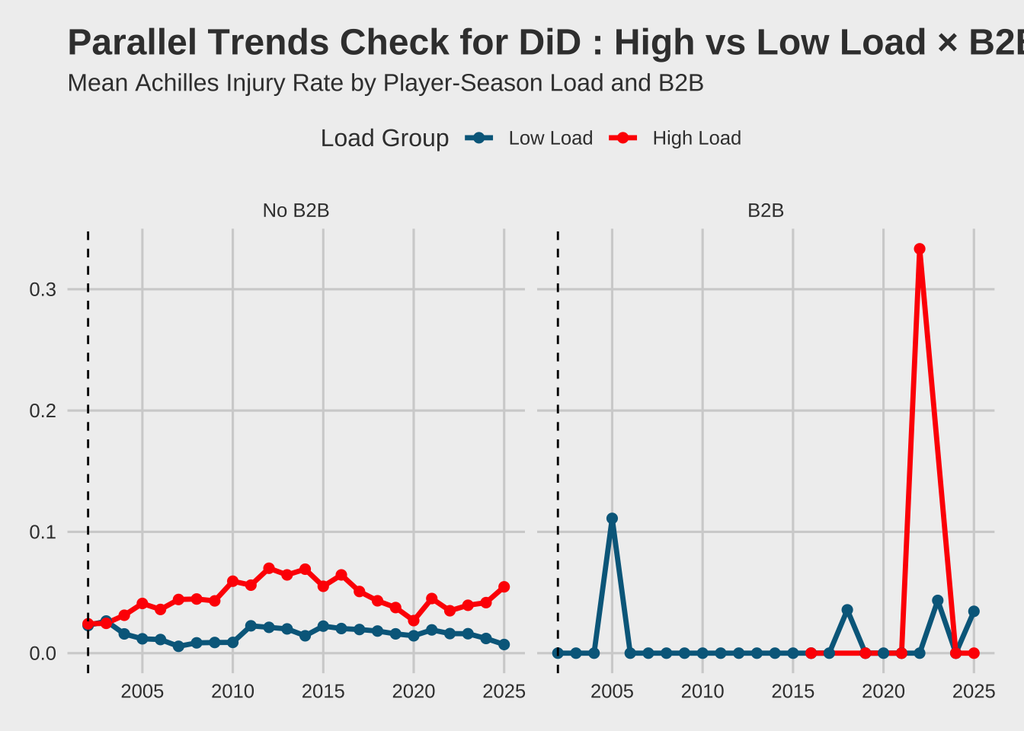

```r
did_parallel_trends
```

From the plot, it is evident that the parallel trends assumption does not hold for B2B games, limiting the reliability of the DiD estimates.

> Injuries are rare and B2B observations are sparse, making estimates sensitive to regression to the mean and unobserved season-specific shocks.

> A synthetic control approach could provide a more robust estimate by constructing a weighted “counterfactual” player-season trajectory, representing what injury risk would have been in the absence of high load or B2B exposure.*(stayed tuned ~)*

## 5. Classification Task: Predicting Rare Achilles Injuries —-

- Now pivoting from WHY, to so **WHO?**

> The gap between intention and actual preventive action for Achilles injuries is concerning. A classification model that flags players at heightened risk—even if those cases are extremely rare—could provide a critical early warning system, enabling targeted prevention strategies like strength conditioning, load management, and biomechanical training based on data-driven metrics and not just the gut feelings of coaches, staff and players.

> Athletic training and rehabilitation research suggests that up to 70% of Achilles ruptures and tendinopathies are preventable with appropriate interventions. Proactive risk detection could shift the balance from reaction to prevention, helping to avert career-altering injuries (Maffulli N 2011; Plas 2012).

Checking Class imbalance first –> Achilles injury is a rare event - **Major Class Imbalance** - need to run either `upsample`, `ROSE`, `SMOTE` and `ADASYN` sampling methods to address such imbalances or in this case rare event occurrences.

```r
achilles_PROPORTION <-
  nba_ncaa_FINAL_MERGE %>%
  count(injured_achilles) %>%
  mutate(prop = (n / sum(n)) * 100)

prop_achilles <-
  achilles_PROPORTION %>%
  filter(injured_achilles == 1) %>%
  pull(prop)

print(glue("The proportion of achilles injuries is: {round(prop_achilles, 2)}%"))
```

```
## The proportion of achilles injuries is: 1.86%
```

```r
### --- Y outcome variable(s) of interest ----
# ~ Setting injured_achilles as a factor for classification
# ~ relevel for reference category --> injured being 1 --> predicting injury NOT non-injury
nba_ncaa_FINAL_MERGE <-
  nba_ncaa_FINAL_MERGE %>%
  mutate(across(where(is.character), as.factor),
         injured_achilles = as.factor(injured_achilles),
         injured_achilles = fct_relevel(injured_achilles,
                                   "1"),
         player_name = as.factor(player_name)
  )

nba_ncaa_FINAL_MERGE %>%
  glimpse()
```

```
## Rows: 16,003
## Columns: 15
## $ player_name        <fct> A.J. Guyton, A.J. Guyton, A.J. Lawson, A.J. Lawson,…
## $ season             <dbl> 2002, 2003, 2023, 2024, 2025, 2010, 2011, 2012, 201…
## $ rolling_minutes_3  <dbl> 8.782486, 3.277778, 1.465517, 3.421811, 16.517857, …
## $ total_minutes      <dbl> 1214, 18, 218, 686, 970, 1726, 1756, 1148, 2552, 19…
## $ total_points       <dbl> 488, 0, 112, 294, 472, 820, 730, 348, 882, 88, 266,…
## $ total_rebounds     <dbl> 88, 0, 42, 106, 172, 176, 158, 126, 228, 20, 64, 90…
## $ total_assists      <dbl> 162, 4, 4, 40, 62, 212, 234, 174, 410, 26, 92, 44, …
## $ total_steals       <int> 20, 2, 4, 20, 26, 70, 64, 40, 66, 2, 14, 12, 18, 76…
## $ total_blocks       <int> 14, 0, 0, 8, 12, 6, 2, 4, 6, 0, 0, 0, 8, 16, 24, 4,…
## $ total_turnovers    <int> 74, 2, 6, 28, 30, 118, 120, 64, 128, 14, 28, 18, 26…
## $ total_fouls        <int> 46, 0, 22, 46, 88, 106, 132, 60, 146, 10, 30, 62, 1…
## $ back_to_back_games <dbl> 17, 0, 2, 10, 4, 22, 21, 23, 20, 14, 9, 8, 13, 15, …
## $ injured_achilles   <fct> 0, 0, 0, 0, 0, 0, 0, 0, 0, 0, 0, 0, 0, 0, 0, 0, 0, …
## $ games_played       <int> 118, 6, 58, 162, 56, 164, 174, 154, 152, 110, 70, 1…
## $ league             <fct> NBA, NBA, NBA, NBA, NBA, NBA, NBA, NBA, NBA, NBA, N…
```

```r
## ==== VIZ/MODEL ====

### Correlation Matrix ----
corr_data <-
  nba_ncaa_FINAL_MERGE %>%
  select(rolling_minutes_3, total_minutes, total_points, total_rebounds,
         total_assists,total_steals, total_blocks, total_turnovers,
         total_fouls, games_played) %>%
  mutate(across(everything(), ~ ifelse(is.na(.), median(., na.rm = TRUE), .)
                )
         )

corr_matrix <-
  corr_data %>%
  select(where(is.numeric)) %>%
  drop_na() %>%
  as.matrix() %>%
  Hmisc::rcorr() %>%
  broom::tidy() %>%
  mutate(absCORR = abs(estimate)) %>%
  select(column1, column2, absCORR) %>%
  DT::datatable() %>%
  formatRound(columns = "absCORR", digits = 3)

corr_matrix
```

|  | column1 | column2 | absCORR |
| --- | --- | --- | --- |
| 1 | total_minutes | rolling_minutes_3 | 0.9523117486047493 |
| 2 | total_points | rolling_minutes_3 | 0.8981008249730559 |
| 3 | total_points | total_minutes | 0.9338136953377921 |
| 4 | total_rebounds | rolling_minutes_3 | 0.8041566369217876 |
| 5 | total_rebounds | total_minutes | 0.8467899419838015 |
| 6 | total_rebounds | total_points | 0.7977279369962664 |
| 7 | total_assists | rolling_minutes_3 | 0.7578789434154559 |
| 8 | total_assists | total_minutes | 0.7855678131849676 |
| 9 | total_assists | total_points | 0.8024529318533998 |
| 10 | total_assists | total_rebounds | 0.5493081076932796 |

[output cut: 35 more lines]

### PREDICTIVE MODELLING

```r
# ---- PREDICTIVE MODEL ----
# Supervised Machine Learning Model --> RF + XGB ~ based on numeric input features
# Big 5:
## ---- Step 1. Data Split ----
set.seed(2025)

achilles_SPLIT <-
  nba_ncaa_FINAL_MERGE %>%
  initial_split(prop = 0.80,
                strata = "injured_achilles")

achilles_TRAIN <-
  achilles_SPLIT %>%
  training()

achilles_TEST <-
  achilles_SPLIT %>%
  testing()

nrow(achilles_TRAIN) + nrow(achilles_TEST) == nrow(nba_ncaa_FINAL_MERGE)
```

```
## [1] TRUE
```

```r
## ---- Step 2. Pre-Processing (FEATURE ENGINEERING) ----
base_recipe <-
  recipe(injured_achilles ~ ., data = achilles_TRAIN) %>%
  step_rm(player_name, league) %>%
  step_zv(all_predictors()) %>%
  step_impute_median(all_numeric_predictors()) %>%
  step_normalize(all_numeric_predictors()) %>%
  step_dummy(all_nominal_predictors())
```

```r
### -> 2.1 upsample
recipe_upsample <-
  base_recipe %>%
  step_upsample(injured_achilles)
```

```r
### -> 2.2 ROSE
recipe_rose <-
  base_recipe %>%
  step_rose(injured_achilles)
```

```r
### -> 2.3 SMOTE
recipe_smote <-
  base_recipe %>%
  step_smote(injured_achilles)
```

```r
### -> 2.4 ADASYN
recipe_adasyn <-
  base_recipe %>%
  step_adasyn(injured_achilles)
```

```r
## ---- Step 3. Model Fit ----
pacman::p_load(parsnip)
### 3.a -> RF (model)
rf <-
  rand_forest() %>%
  set_args(trees = 300L,
           mtry = tune()
           ) %>%
  set_engine("ranger") %>%
  set_mode("classification")

rf
```

```
## Random Forest Model Specification (classification)
##
## Main Arguments:
##   mtry = tune()
##   trees = 300
##
## Computational engine: ranger
```

```r
### 3.b -> XGBOOST model
pacman::p_load(xgboost)
xgb <-
  boost_tree(trees = 300L,
             tree_depth = tune(),
             mtry = tune(),
             learn_rate = tune(),
             loss_reduction = tune(),
             sample_size = tune()
  ) %>%
  set_engine("xgboost") %>%
  set_mode("classification")
```

- `workflow()` ~ here we are building **9 Algorithms** (5 for Random Forest; 4 for eXtreme Gradien Boosting)
- NOTE: not recommended to do upsample for boosting models –> so that is omitted
- 1. no-sampling; 2. upsample(not for xgb), 3. smote, 4. rose, 5.adasyn

```r
## ---- Step 4. Hyper-Parameter Tuning ----
### 4.1 workflow sets ----

###   -> 1. RF + no sampling
rf_none <-
  workflow() %>%
  add_recipe(base_recipe) %>%
  add_model(rf)
```

```r
###   -> 2. RF + upsample
rf_upsample <-
  workflow() %>%
  add_recipe(recipe_upsample) %>%
  add_model(rf)
```

```r
###   -> 3. RF + SMOTE
rf_smote <-
  workflow() %>%
  add_recipe(recipe_smote) %>%
  add_model(rf)
```

```r
###   -> 4. RF + ROSE
rf_rose <-
  workflow() %>%
  add_recipe(recipe_rose) %>%
  add_model(rf)
```

```r
###   -> 5. RF + ADASYN
rf_adasyn <-
  workflow() %>%
  add_recipe(recipe_adasyn) %>%
  add_model(rf)
```

```r
###   -> 6. XGB + no sampling
xgb_none <-
  workflow() %>%
  add_recipe(base_recipe) %>%
  add_model(xgb)
```

```r
###   -> 7. XGB + SMOTE
xgb_smote <-
  workflow() %>%
  add_recipe(recipe_smote) %>%
  add_model(xgb)
```

```r
###   -> 8. XGB + ROSE
xgb_rose <-
  workflow() %>%
  add_recipe(recipe_rose) %>%
  add_model(xgb)
```

```r
###   -> 9. XGB + ADASYN
xgb_adasyn <-
  workflow() %>%
  add_recipe(recipe_adasyn) %>%
  add_model(xgb)
```

- This step is optional and additional. As our laptops were not running this fast enough.

```r
### 4.2 parallel processing
registerDoParallel()

cl <- makeCluster(detectCores())  # Use all available cores
registerDoParallel(cl)
```

```r
### 4.3 CV
set.seed(2025)

cv_5 <-
  achilles_TRAIN %>%
  vfold_cv(v = 5,
           strata = injured_achilles)
```

```r
### 4.4 tune grid
grid_for_rf <-
  expand.grid(mtry = c(3:5) # 3,4,5
  )

grid_for_xgb <-
  grid_space_filling(
    # trees = 500L,
                     tree_depth(), # n of boosting rounds & depth of each tree
                     learn_rate(), # shrinkage
                     loss_reduction(), # gamma
                     sample_size = sample_prop(),
                     finalize(mtry(), achilles_TRAIN),
                     size = 15
  )
```

```r
# GAME CHANGER!!! workflowsets::workflow_set()
pacman::p_load(workflowsets)

# various models for RF
wf_rf <-
  workflow_set(preproc = list(rf_none_TUNED = base_recipe,
                              rf_upsample_TUNED = recipe_upsample,
                              rf_smote_TUNED = recipe_smote,
                              rf_rose_TUNED = recipe_rose,
                              rf_adasyn_TUNED = recipe_adasyn),
               models = list(rf = rf)
)

# various models for XGBOOST
wf_xgb <-
  workflow_set(preproc = list(xgb_none_TUNED = base_recipe,
                              xgb_smote_TUNED = recipe_smote,
                              xgb_rose_TUNED = recipe_rose,
                              xgb_adasyn_TUNED = recipe_adasyn),
               models = list(xgb = xgb)
                       )
wf_set <-
  bind_rows(wf_rf, wf_xgb)
```

```r
# Run tuning on RF workflows only
pacman::p_load(future,doParallel,tune,workflows)

foreach::registerDoSEQ()
plan(multisession, workers = parallel::detectCores() - 1)

rf_results <-
  workflow_map(
    wf_rf,
    "tune_grid",
    resamples = cv_5,
    grid = grid_for_rf,
    control = control_grid(save_pred = TRUE,
                           verbose = FALSE,
                           allow_par = TRUE)
)

saveRDS(rf_results, "rf_results.rds")

rf_printed_ranks <-
rank_results(rf_results,
             rank_metric = "accuracy") %>%
  arrange(rank)
```

```r
stopImplicitCluster()

foreach::registerDoSEQ()
plan(multisession, workers = parallel::detectCores() - 1)

# Run tuning on XGB workflows only
xgb_results <-
  workflow_map(
  wf_xgb,
  "tune_grid",
  resamples = cv_5,
  grid = grid_for_xgb,
  control = control_grid(save_pred = TRUE,
                         verbose = FALSE,
                         allow_par = TRUE)
)

saveRDS(xgb_results, "xgb_results.rds")

xgb_printed_ranks <-
rank_results(xgb_results,
             rank_metric = "accuracy") %>%
  arrange(rank)
```

```r
### 4.5 select best

### -> FOR RF MODELS [5]
rf_none_PARAMS <-
  workflowsets::extract_workflow_set_result(rf_results,
                                            id = "rf_none_TUNED_rf") %>%
  select_best(metric = "roc_auc")

rf_upsample_PARAMS <-
  workflowsets::extract_workflow_set_result(rf_results,
                                            id = "rf_upsample_TUNED_rf") %>%
  select_best(metric = "roc_auc")

rf_rose_PARAMS <-
  workflowsets::extract_workflow_set_result(rf_results,
                                            id = "rf_rose_TUNED_rf") %>%
  select_best(metric = "roc_auc")

rf_smote_PARAMS <-
  workflowsets::extract_workflow_set_result(rf_results,
                                            id = "rf_smote_TUNED_rf") %>%
  select_best(metric = "roc_auc")

rf_adasyn_PARAMS <-
  workflowsets::extract_workflow_set_result(rf_results,
                                            id = "rf_adasyn_TUNED_rf") %>%
  select_best(metric = "roc_auc")

### -> FOR XGB MODELS [4]
xgb_none_PARAMS <-
  workflowsets::extract_workflow_set_result(xgb_results,
                                            id = "xgb_none_TUNED_xgb") %>%
  select_best(metric = "roc_auc")

xgb_smote_PARAMS <-
  workflowsets::extract_workflow_set_result(xgb_results,
                                            id = "xgb_smote_TUNED_xgb") %>%
  select_best(metric = "roc_auc")

xbg_rose_PARAMS <-
  workflowsets::extract_workflow_set_result(xgb_results,
                                            id = "xgb_rose_TUNED_xgb") %>%
  select_best(metric = "roc_auc")

xgb_adasyn_PARAMS <-
  workflowsets::extract_workflow_set_result(xgb_results,
                                            id = "xgb_adasyn_TUNED_xgb") %>%
  select_best(metric = "roc_auc")
```

```r
### 4.6 finalized workflow

### -> FOR RF MODELS [5]
rf_none_FINALIZED  <-
  rf_none %>%
  finalize_workflow(rf_none_PARAMS)

rf_upsample_FINALIZED  <-
  rf_upsample %>%
  finalize_workflow(rf_upsample_PARAMS)

rf_rose_FINALIZED  <-
  rf_rose %>%
  finalize_workflow(rf_rose_PARAMS)

rf_smote_FINALIZED  <-
  rf_smote %>%
  finalize_workflow(rf_smote_PARAMS)

rf_adasyn_FINALIZED  <-
  rf_adasyn %>%
  finalize_workflow(rf_adasyn_PARAMS)


### -> FOR XGB MODELS [4]

xgb_none_FINALIZED  <-
  xgb_none %>%
  finalize_workflow(xgb_none_PARAMS)

xgb_smote_FINALIZED  <-
  xgb_smote %>%
  finalize_workflow(xgb_smote_PARAMS)

xgb_rose_FINALIZED  <-
  xgb_rose %>%
  finalize_workflow(xbg_rose_PARAMS)

xgb_adasyn_FINALIZED  <-
  xgb_adasyn %>%
  finalize_workflow(xgb_adasyn_PARAMS)
```

```r
### 4.7 last fit
rf_none_FIT <-
  rf_none_FINALIZED %>%
  last_fit(achilles_SPLIT)

rf_upsample_FIT <-
  rf_upsample_FINALIZED %>%
  last_fit(achilles_SPLIT)

rf_rose_FIT <-
  rf_rose_FINALIZED %>%
  last_fit(achilles_SPLIT)

rf_smote_FIT <-
  rf_smote_FINALIZED %>%
  last_fit(achilles_SPLIT)

rf_adasyn_FIT <-
  rf_adasyn_FINALIZED %>%
  last_fit(achilles_SPLIT)

xgb_none_FIT <-
  xgb_none_FINALIZED %>%
  last_fit(achilles_SPLIT)

xgb_smote_FIT <-
  xgb_smote_FINALIZED %>%
  last_fit(achilles_SPLIT)

xgb_rose_FIT <-
  xgb_rose_FINALIZED %>%
  last_fit(achilles_SPLIT)

xgb_adasyn_FIT <-
  xgb_adasyn_FINALIZED %>%
  last_fit(achilles_SPLIT)
```

Step 5: Assess the models

```r
A <-
  rf_none_FIT %>%
  collect_metrics() %>%
  mutate(algorithm = "RF without sampling")

B <-
  rf_upsample_FIT %>%
  collect_metrics() %>%
  mutate(algorithm = "RF with upsampling")

C <-
  rf_rose_FIT %>%
  collect_metrics() %>%
  mutate(algorithm = "RF with ROSE")

D <-
  rf_smote_FIT %>%
  collect_metrics() %>%
  mutate(algorithm = "RF with SMOTE")

E <-
  rf_adasyn_FIT %>%
  collect_metrics() %>%
  mutate(algorithm = "RF with ADASYN")

XGB1 <-
  xgb_none_FIT %>%
  collect_metrics() %>%
  mutate(algorithm = "XGB without sampling")

XGB2 <-
  xgb_rose_FIT %>%
  collect_metrics() %>%
  mutate(algorithm = "XGB with ROSE")

XGB3 <-
  xgb_smote_FIT %>%
  collect_metrics() %>%
  mutate(algorithm = "XGB with SMOTE")

XGB4 <-
  xgb_adasyn_FIT %>%
  collect_metrics() %>%
  mutate(algorithm = "XGB with ADASYN")

comparison_of_performance <-
  bind_rows(A, B, C, D, E, XGB1, XGB2, XGB3, XGB4)

comparison_of_performance %>%
  select(-.estimator, -.config) %>%
  pivot_wider(names_from = .metric, values_from = .estimate) %>%
  datatable() %>%
  formatRound(c("accuracy", "roc_auc"), digits = 3)
```

|  | algorithm | accuracy | roc_auc | brier_class |
| --- | --- | --- | --- | --- |
| 1 | RF without sampling | 0.9837550765385817 | 0.8346308653744214 | 0.01409547385195134 |
| 2 | RF with upsampling | 0.9837550765385817 | 0.8181160187833191 | 0.0154979490347646 |
| 3 | RF with ROSE | 0.9497032177444549 | 0.7832562463957442 | 0.04177690172111437 |
| 4 | RF with SMOTE | 0.9775070290534208 | 0.806564747143075 | 0.02769661994462039 |
| 5 | RF with ADASYN | 0.9750078100593564 | 0.8122020972354626 | 0.02908452561392781 |
| 6 | XGB without sampling | 0.9840674789128397 | 0.8598430015652905 | 0.0138715991884124 |
| 7 | XGB with ROSE | 0.9615745079662605 | 0.7876813896832993 | 0.03589467421305001 |
| 8 | XGB with SMOTE | 0.7778819119025304 | 0.8085566500723792 | 0.2499996375683366 |
| 9 | XGB with ADASYN | 0.6757263355201499 | 0.8093598841930585 | 0.2499997015115597 |

### 6. DEPLOYING our AI MODEL

```r
AI_MODEL <-
  xgb_none_FINALIZED %>%
  fit(nba_ncaa_FINAL_MERGE)
```

Now that we’ve built our AI Model, to explore potential future injury risk, we focus on the **top 20 healthy NBA players from the 2024 season** who logged the most playing time. These players had no prior Achilles injuries and meet a threshold for meaningful playtime, making them suitable candidates for prediction using our trained model.

```r
# taking the top 20 healthy players who played the most in the past year (i.e 2024)
healthy_players <-
  nba_ncaa_FINAL_MERGE %>%
  group_by(player_name) %>%
  filter(all(injured_achilles == 0)) %>%  # no Achilles injuries in any season
  ungroup()

# Optional: keep only recent season (e.g., 2024)
recent_healthy_players <-
  healthy_players %>%
  filter(season == 2024) %>%
  filter(total_minutes > 500) # threshold for meaningful playtime

# Take distinct players with summary stats by last season
future_candidates <-
  recent_healthy_players %>%
  select(player_name, season, rolling_minutes_3, total_minutes, total_points, total_rebounds,
         total_assists, total_steals, total_blocks, total_turnovers, total_fouls,
         games_played, back_to_back_games, league) %>%
  distinct(player_name, .keep_all = TRUE)

# remove those injured folks
injured_this_season <-
  c("Tyrese Haliburton", "Jayson Tatum", "Damian Lillard",
    "Dejounte Murray", "James Wiseman", "Isaiah Jackson", "Dru Smith")

future_candidates <-
  future_candidates %>%
  filter(!player_name %in% injured_this_season)

future_players_to_predict <-
  future_candidates %>%
  arrange(desc(total_minutes)) %>%
  slice_head(n = 20)

future_players_to_predict %>% head()
```

| player_name | season | rolling_minutes_3 | total_minutes | total_points | total_rebounds | total_assists | total_steals | total_blocks | total_turnovers | total_fouls | games_played | back_to_back_games | league |
| --- | --- | --- | --- | --- | --- | --- | --- | --- | --- | --- | --- | --- | --- |
| Luka Doncic | 2.02e+03 | 37.9 | 7.09e+03 | 6.02e+03 | 1.72e+03 | 1.74e+03 | 280 | 92 | 746 | 410 | 186 | 9 | NBA |
| Anthony Edwards | 2.02e+03 | 35.8 | 6.87e+03 | 4.99e+03 | 1.09e+03 | 1.02e+03 | 250 | 102 | 586 | 356 | 192 | 13 | NBA |
| Jalen Brunson | 2.02e+03 | 32.8 | 6.53e+03 | 5.29e+03 | 650 | 1.24e+03 | 162 | 30 | 444 | 340 | 192 | 13 | NBA |
| Pascal Siakam | 2.02e+03 | 33 | 6.53e+03 | 4.21e+03 | 1.39e+03 | 812 | 152 | 64 | 320 | 482 | 196 | 12 | NBA |
| Josh Hart | 2.02e+03 | 34.5 | 6.51e+03 | 1.9e+03 | 1.65e+03 | 780 | 176 | 66 | 304 | 424 | 188 | 12 | NBA |
| Nikola Jokic | 2.02e+03 | 35.2 | 6.48e+03 | 4.88e+03 | 2.28e+03 | 1.64e+03 | 254 | 152 | 556 | 454 | 184 | 12 | NBA |

```r
# Predict probabilities
pred_probs <-
  AI_MODEL %>%
  predict(future_players_to_predict, type = "prob") %>%
  bind_cols(future_players_to_predict %>%
              select(player_name, season, league, total_minutes)
            )
# Adding predicted class based on threshold (e.g., 0.1)
threshold <- 0.1

pred_probs <-
  pred_probs %>%
  mutate(pred_class = ifelse(.pred_1 >= 0.1, "High Risk", "Low Risk")
         ) %>%
  arrange(desc(.pred_1)
          )
```

```r
# example using  test dataset
test_preds <-
  AI_MODEL %>%
  predict(achilles_TEST,
          type = "prob") %>%
  bind_cols(achilles_TEST %>% select(player_name, injured_achilles)
            ) %>%
  mutate(pred_class = ifelse(.pred_1 >= threshold, 1, 0)
         )
```

To evaluate the performance of our Achilles injury prediction model, we construct a **confusion matrix** comparing predicted classes against the true outcomes in the test set. This allows us to visually inspect **true positives, true negatives, false positives, and false negatives**, providing insight into the model’s accuracy and potential areas for improvement.

```r
# building a confusion matrix
conf_mat <-
  table(test_preds$pred_class, test_preds$injured_achilles)
conf_mat
```

```
##
##        1    0
##   0    3 3142
##   1   51    5
```

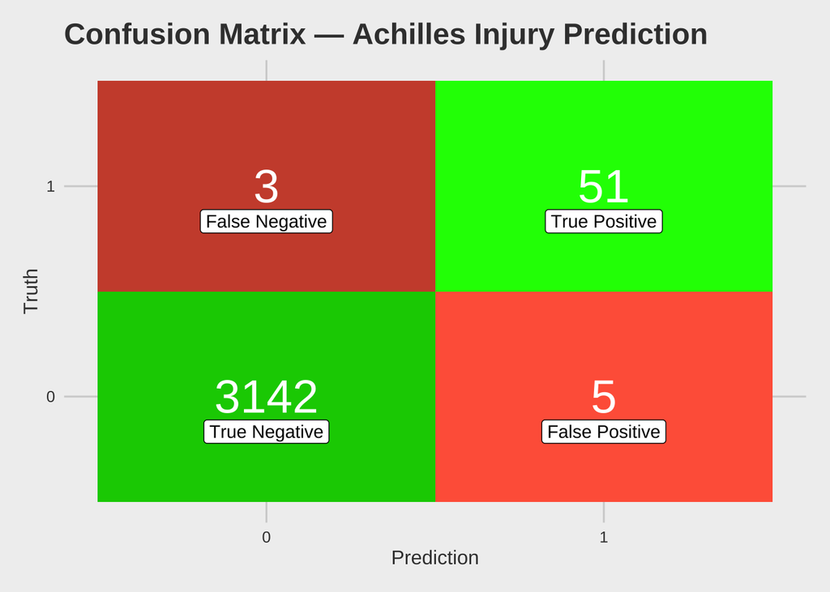

```r
test_preds <-
  test_preds %>%
  mutate(injured_achilles = factor(injured_achilles,
                                   levels = c(1, 0)
                                   ),
    pred_class = factor(pred_class,
                        levels = c(1, 0)
                        )
  )

# Plotting the Confusion Matrix figure
CM_PLOT <-
  test_preds %>%
  conf_mat(truth = injured_achilles, estimate = pred_class) %>%
  pluck(1) %>%
  as_tibble() %>%
  mutate(cm_colors = case_when(
    Truth == "1" & Prediction == "1" ~ "True Positive",
    Truth == "1" & Prediction == "0" ~ "False Negative",
    Truth == "0" & Prediction == "1" ~ "False Positive",
    Truth == "0" & Prediction == "0" ~ "True Negative"
  )) %>%
  ggplot(aes(x = Prediction,
             y = Truth)
         ) +
  geom_tile(aes(fill = cm_colors)
            ) +
  scale_fill_manual(values = c("True Positive" = "green1",
                               "True Negative" = "green3",
                               "False Positive" = "tomato1",
                               "False Negative" = "tomato3")
                    ) +
  geom_text(aes(label = n),
            color = "white",
            size = 10) +
  geom_label(aes(label = cm_colors),
             vjust = 2) +
  labs(title = "Confusion Matrix — Achilles Injury Prediction") +
  ggthemes::theme_fivethirtyeight() +
  theme(axis.title = element_text(),
        legend.position = "none")
CM_PLOT
```

## Future Improvements — Cost-Sensitive Analysis

> The plot below illustrates the mean COR per player, highlighting the substantial economic stakes associated with high-salary athletes.

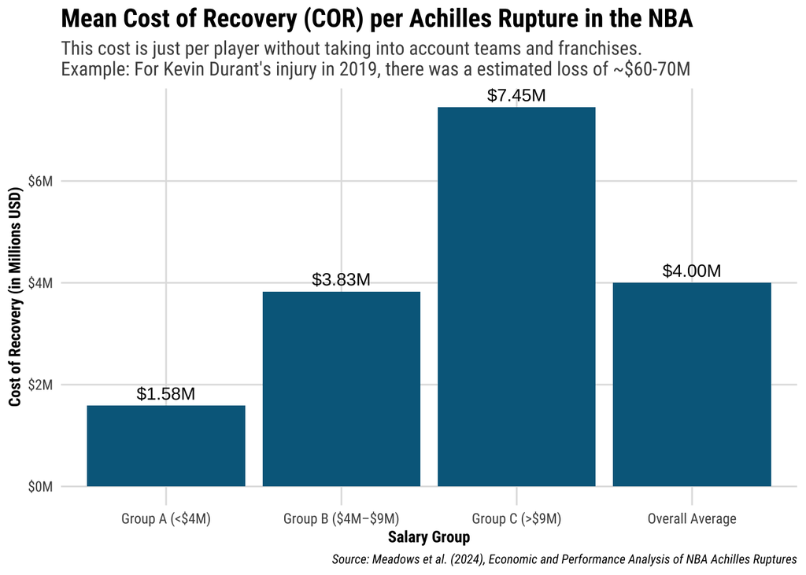

```r
# Simplistic aggregated Data frame (placeholder) with Cost of Recovery (COR) by group
cor_data <-
  tibble(SalaryGroup = c("Group A (<$4M)", "Group B ($4M–$9M)", "Group C (>$9M)", "Overall Average"),
         COR = c(1.585, 3.830, 7.449, 4.0)
)

cor_data %>%
  ggplot(aes(x = SalaryGroup,
           y = COR,
           fill = SalaryGroup)
         ) +
  geom_col(fill = "deepskyblue4",
           show.legend = FALSE) +
  geom_text(aes(label = scales::dollar(COR, suffix = "M")), vjust = -0.5) +
  scale_y_continuous(labels = scales::dollar_format(prefix = "$", suffix = "M")) +
  labs(title = "Mean Cost of Recovery (COR) per Achilles Rupture in the NBA",
       subtitle = paste0("This cost is just per player without taking into account teams and franchises.",
                          "\nExample: For Kevin Durant's injury in 2019, there was a estimated loss of ~$60-70M"),
       x = "Salary Group",
       y = "Cost of Recovery (in Millions USD)",
       caption = "Source: Meadows et al. (2024), Economic and Performance Analysis of NBA Achilles Ruptures"
       ) +
  theme_nba()
```

### Make sure to run sessionInfo()

> Prof. Roh’s Note: “Please include `sessionInfo()` below to document your R session. This logs the R version and package versions used, which is good practice for reproducibility.”

[session information not shown]

## 9. Limitations and Future Directions

> Prof. Roh’s Note: “Acknowledge what your analysis cannot tell and propose what further investigations would be informative.” While our analysis provides valuable insights, it’s important to recognize its limitations:
- `Offseason and Training Data`: Current datasets mostly cover in-season statistics and injuries. The “player today” may be very different from “player last season” due to changes in offseason training, conditioning, or recovery protocols. For meaningful risk prediction, access to granular offseason workload, strength, conditioning, and recovery data is crucial. Future models should incorporate these longitudinal factors to better capture evolving injury risk.
- `Computational Power`: We were unable to run some of the imputes like KNN and better hyper-parameter tuning (number of trees, grids and cv folds) had to be severaly altered and reduced due to lack of computational ability.

`Within-Player Variability`: Even a single athlete can change substantially over time. For example, most recently— **Luka Dončić** has visibly altered his physique in recent seasons, losing a ton of weight and adjusting muscle mass. Such changes could affect load tolerance, biomechanics, and injury risk. Future research should track individualized player profiles, including physical metrics and conditioning trends, to account for these intra-player differences.

`Data Coverage`: Historical data before 2002 and NCAA datasets are limited. Expanding coverage would help assess ground truths better: long-term trends and injury patterns across different contexts.

`Rare Events and Measurement`: Achilles injuries are uncommon and reported inconsistently across public sources. Combining team medical records, wearable sensor outputs, and public data could improve accuracy.

`Parallel Trends & Causal Assumptions`: DID-style causal inference relies on comparable pre-exposure trends. Sparse data and rare events mean assumptions may not fully hold. Synthetic controls or multiple pre-season observations could strengthen causal claims.

`Generalizability`: Findings reflect elite NBA players; extrapolating to younger athletes, other leagues, or international contexts cannot carry over easily

> In conclusion, while our analysis highlights important patterns in Achilles injury risk among NBA players and provides both causal and predictive insights, it represents only a part of the broader picture. A comprehensive understanding requires access to offseason and training data, more granular tracking of individual player changes over time, and integration of longitudinal recovery metrics. The variability within players—such as Luka Dončić’s recent physical transformation—illustrates the need for individualized and evolving data to improve predictions. Future work that incorporates these dimensions will deepen our understanding of injury mechanisms and enhance actionable insights for teams, medical staff, and athletes, helping to mitigate risk while optimizing player performance.

## Contribution Statement

> Prof. Roh’s Note: “Each team member should detail their individual contributions to the project here. For example: data collection by Person A, analysis by Person B, writing by Person C, etc. Be specific about what you personally contributed.”
- `Keziah`: Data Collection, Analysis and contributed to literature review sections
- `Haneeza`: Developed the R Markdown workflow, assisted with literature review, and performed data cross-validation
- `Eugene`: Contributed to literature review and contextual research for the project.

## References

Amin, Nirav H., Andrew B. Old, Loni P. Tabb, Rohit Garg, Nader Toossi, and Douglas L. Cerynik. 2013. “Performance Outcomes After Repair of Complete Achilles Tendon Ruptures in National Basketball Association Players.” *The American Journal of Sports Medicine* 41 (8): 1864–68. https://doi.org/10.1177/0363546513490659.

ESPN. 2025. “NBA Injury Log.” https://www.espn.com.sg/nba/injuries.

Farmer, S. Los Angeles Times. 2013. “Kobe Bryant Has Achilles Tendon Surgery, Out 6 to 9 Months.” https://www.latimes.com/sports/lakers/la-xpm-2013-apr-13-la-sp-ln-kobe-bryant-achilles-injury-update-20130413-story.html.

Fischer, B. Fox Sports. 2025. “Three Achilles Injuries in One NBA Postseason: What’s Going on and How Is It Fixed?” https://www.foxsports.com/stories/nba/three-achilles-injuries-in-one-nba-postseason-whats-going-on-and-how-is-it-fixed.

Gilani, Saiem. 2021. “hoopR: The SportsDataverse’s r Package for Men’s Basketball Data.” https://hoopR.sportsdataverse.org.

Hart, SI, T. 2019. “How Achilles Injuries Affected These Nine NBA Players.” https://www.si.com/nba/2019/06/11/kevin-durant-achilles-injury-news-recovery-history.

Kuhn, & Silge, M. 2022. “Tidy Modeling with r. O’reilly Media.” https://www.tmwr.org.

Kumar, Fadeway World, V. 2025. “From 1990 to 2023, 45 NBA Players Suffered Achilles Tears — but 8 Have Already Occurred This Season.” https://fadeawayworld.net/nba-media/from-1990-2023-45-nba-players-suffered-achilles-tears-8-occurred-season.

LaPrade, Christopher M, Deepak V Chona, Mark E Cinque, Michael T Freehill, Timothy R McAdams, Geoffrey D Abrams, Seth L Sherman, and Marc R Safran. 2022. “Return-to-Play and Performance After Operative Treatment of Achilles Tendon Rupture in Elite Male Athletes: A Scoping Review.” *British Journal of Sports Medicine* 56 (9): 515–20. https://doi.org/10.1136/bjsports-2021-104835.

Lauton, L. 2023. “NBA Injury Stats (1951 - 2023).” https://www.kaggle.com/datasets/loganlauton/nba-injury-stats-1951-2023.

Lewis, D. Bleacher Report. 2014. “Kobe Bryant: Orthopaedic Surgeon Discusses Star’s Achilles Tendon, Knee Injuries.” https://bleacherreport.com/articles/2224150-kobe-bryant-orthopaedic-surgeon-discusses-stars-achilles-tendon-knee-injuries.

Maffulli N, Maffulli GD, Longo UG. 2011. “Achilles Tendon Ruptures in Elite Athletes.” *Foot & Ankle International* 32 (1): 9–15. https://doi.org/10.3113/FAI.2011.0009.

Petway, Adam J., Matthew J. Jordan, Scott Epsley, and Philip Anloague. 2022. “Mechanisms of Achilles Tendon Rupture in National Basketball Association Players.” *Journal of Applied Biomechanics* 38 (6): 398–403. https://doi.org/10.1123/jab.2022-0088.

Plas, de Jonge van der, A. 2012. “A 5-Year Follow-up Study of Alfredson’s Heel-Drop Exercise Programme in Chronic Midportion Achilles Tendinopathy.” *British Journal of Sports Medicine* 46 (3): 214–18. https://doi.org/10.1136/bjsports-2011-090035.

Press, The Associated. 2025. “Adam Silver Says League Taking Serious Look at Achilles Tears.” https://www.espn.com.sg/nba/story/_/id/45585272/adam-silver-says-league-taking-serious-look-achilles-tears.

Reynolds, T. The Associated Press. 2025. “NBA Commissioner Adam Silver Says League Taking Closer Look at Achilles Tears.” https://www.nba.com/news/nba-commissioner-adam-silver-league-researching-achilles-tears.

Siu, Ronald, Samuel KK. Ling, Naomi Fung, Nigel Pak, and Patrick SH. Yung. 2020. “Prognosis of Elite Basketball Players After an Achilles Tendon Rupture.” *Asia-Pacific Journal of Sports Medicine, Arthroscopy, Rehabilitation and Technology* 21 (July): 5–10. https://doi.org/10.1016/j.asmart.2020.03.002.

Trofa, David P., J. Chance Miller, Eugene S. Jang, Denzel R. Woode, Justin K. Greisberg, and J. Turner Vosseller. 2017. “Professional Athletes’ Return to Play and Performance After Operative Repair of an Achilles Tendon Rupture.” *The American Journal of Sports Medicine* 45 (12): 2864–71. https://doi.org/10.1177/0363546517713001.